# PSC study: Q3

## Results overview

#### Alpha diversity

```r
pc_observed[[segment]]
```

|  | Estimate | Std..Error | t.value | Pr...t.. | p.adj | sig |
| --- | --- | --- | --- | --- | --- | --- |
| no_ibd vs Groupibd | -41.18605 | 24.04109 | -1.7131524 | 0.08981453 | 0.08981453 |  |
| no_ibd , ibd - CZ vs NO | -25.63636 | 27.44299 | -0.9341681 | 0.35249010 | 0.35249010 |  |
| no_ibd vs Groupibd:CountryNO | 34.57241 | 29.53236 | 1.1706618 | 0.24454493 | 0.24454493 |  |

```r
pc_shannon[[segment]]
```

|  | Estimate | Std..Error | t.value | Pr...t.. | p.adj | sig |
| --- | --- | --- | --- | --- | --- | --- |
| no_ibd vs Groupibd | -0.4383750 | 0.3249580 | -1.349021 | 0.1804078 | 0.1804078 |  |
| no_ibd , ibd - CZ vs NO | -0.4527872 | 0.3709407 | -1.220646 | 0.2251195 | 0.2251195 |  |
| no_ibd vs Groupibd:CountryNO | 0.4709943 | 0.3991823 | 1.179898 | 0.2408684 | 0.2408684 |  |

```r
pc_simpson[[segment]]
```

|  | Estimate | Std..Error | t.value | Pr...t.. | p.adj | sig |
| --- | --- | --- | --- | --- | --- | --- |
| no_ibd vs Groupibd | -0.04270873 | 0.04255231 | -1.0036759 | 0.3179818 | 0.3179818 |  |
| no_ibd , ibd - CZ vs NO | -0.04732652 | 0.04857361 | -0.9743258 | 0.3322695 | 0.3322695 |  |
| no_ibd vs Groupibd:CountryNO | 0.04523313 | 0.05227177 | 0.8653452 | 0.3889415 | 0.3889415 |  |

```r
pc_pielou[[segment]]
```

|  | Estimate | Std..Error | t.value | Pr...t.. | p.adj | sig |
| --- | --- | --- | --- | --- | --- | --- |
| no_ibd vs Groupibd | -0.04155283 | 0.04564020 | -0.9104437 | 0.3648000 | 0.3648000 |  |
| no_ibd , ibd - CZ vs NO | -0.06798100 | 0.05209845 | -1.3048566 | 0.1949666 | 0.1949666 |  |
| no_ibd vs Groupibd:CountryNO | 0.05643578 | 0.05606497 | 1.0066139 | 0.3165744 | 0.3165744 |  |

Plots

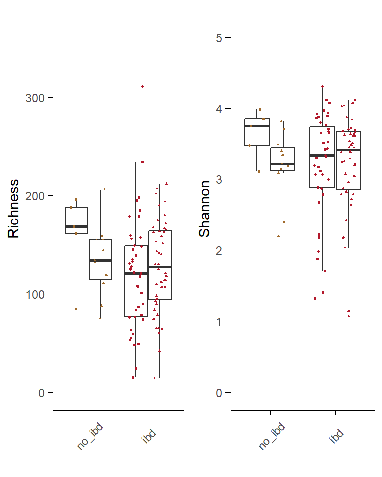

```r
alpha_div_plots[[paste(segment,"Country")]]
```

#### Beta diversity

**Main results**

```r
pairwise_aitchison_raw[[paste("genus", segment)]]
```

| pairs | Df | SumsOfSqs | F.Model | R2 | p.value | p.adjusted | sig |
| --- | --- | --- | --- | --- | --- | --- | --- |
| no_ibd vs ibd | 1 | 204.8971 | 1.1481631 | 0.011019690 | 0.175 | 0.175 |  |
| no_ibd vs ibd , Country | 1 | 562.9855 | 3.1547500 | 0.030278249 | 0.001 | 0.001 | *** |
| no_ibd vs ibd : Country | 1 | 168.9419 | 0.9461745 | 0.009085961 | 0.564 | 0.564 |  |

*PCA*

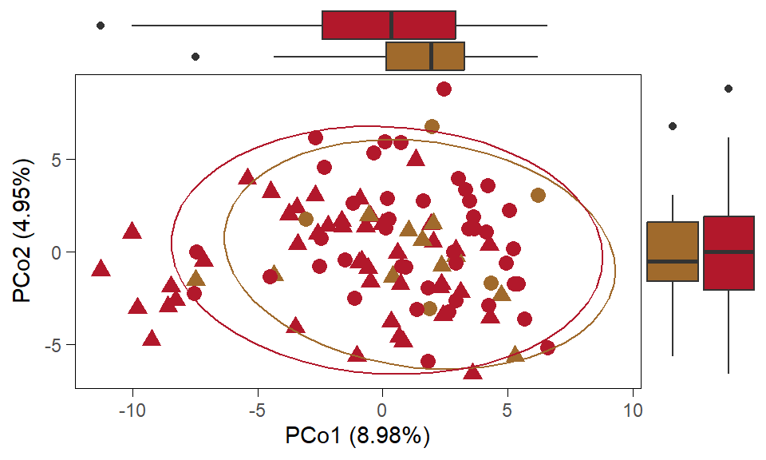

```r
pca_plots_list[[paste(segment,"genus custom")]]
```

**Supplements**

```r
knitr::kable(supplements_beta[!grepl("PCoA",names(supplements_beta)) & (grepl("genus",names(supplements_beta)))],
             digits = 3,
             caption = "Supplementary PERMANOVA results: Bray-curtis, Jaccard distances")
```

Supplementary PERMANOVA results: Bray-curtis, Jaccard distances

| pairs | Df | SumsOfSqs | F.Model | R2 | p.value | p.adjusted | sig |
| --- | --- | --- | --- | --- | --- | --- | --- |
| no_ibd vs ibd | 1 | 0.258 | 1.089 | 0.010 | 0.327 | 0.327 |  |
| no_ibd vs ibd , Country | 1 | 1.245 | 5.252 | 0.049 | 0.001 | 0.001 | *** |
| no_ibd vs ibd : Country | 1 | 0.111 | 0.464 | 0.004 | 0.970 | 0.970 |  |

| pairs | Df | SumsOfSqs | F.Model | R2 | p.value | p.adjusted | sig |
| --- | --- | --- | --- | --- | --- | --- | --- |
| no_ibd vs ibd | 1 | 0.333 | 1.048 | 0.010 | 0.350 | 0.350 |  |
| no_ibd vs ibd , Country | 1 | 1.179 | 3.711 | 0.035 | 0.001 | 0.001 | *** |
| no_ibd vs ibd : Country | 1 | 0.203 | 0.637 | 0.006 | 0.977 | 0.977 |  |

*PCA*

```r
ggarrange(plotlist = supplements_beta[grepl("PCoA",names(supplements_beta))],
          labels=names(supplements_beta[grepl("PCoA",names(supplements_beta))]),
          font.label = list(size=5,face="plain"),
          ncol=2,nrow=3)
```

[output not shown]

#### Univariate analysis

**Number of significant taxa**

```r
knitr::kable(as.data.frame(lapply(list_intersections,nrow)) %>% t() %>%
  `colnames<-`("Count") %>%
  `rownames<-`(c(names(list_intersections))),caption="Number of significant taxa")
```

Number of significant taxa

|  | Count |
| --- | --- |
| terminal_ileum genus no_ibd vs ibd | 0 |
| terminal_ileum ASV no_ibd vs ibd | 1 |
| terminal_ileum phylum no_ibd vs ibd | 0 |

#### Machine learning

**Main models**

```r
knitr::kable(models_summ_df_ileum %>% dplyr::select(
"alpha","lambda",
"auc_optimism_corrected",
"auc_optimism_corrected_CIL",
"auc_optimism_corrected_CIU"),
             digits=2,caption="Elastic net results")
```

Elastic net results

|  | alpha | lambda | auc_optimism_corrected | auc_optimism_corrected_CIL | auc_optimism_corrected_CIU |
| --- | --- | --- | --- | --- | --- |
| ibd vs no_ibd ASV terminal_ileum | 0 | 149.36 | 0.42 | 0.04 | 0.62 |
| no_ibd vs ibd genus terminal_ileum | 1 | 0.12 | 0.58 | 0.30 | 0.80 |

**ROC - Genus level**

```
## [1] "no_ibd vs ibd genus terminal_ileum"
```

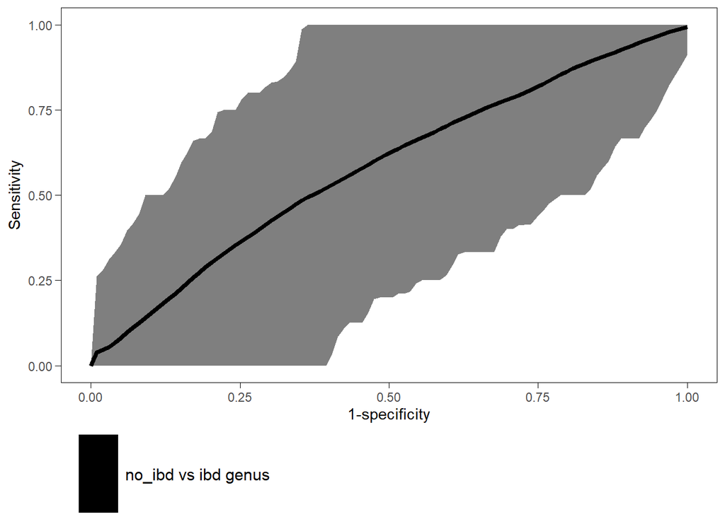

```r
roc_curve_all_custom(roc_cs[2],Q="Q3",
                     model_name="enet_model")
```

**Supplementary models**

```r
# Build final dataframe
models_list[["enet_model"]] <- models_summ_df_ileum
final_df <- tibble(row_names = rownames(models_list[[1]]))

# Loop through models and extract required values
for (model_name in names(models_list)) {
  model_df <- models_list[[model_name]]

  # Combine AUC_optimism_corrected with its CI values
  final_df[[model_name]] <- paste0(
    round(model_df$auc_optimism_corrected, 3),
    " (", round(model_df$auc_optimism_corrected_CIL, 3), "; ",
    round(model_df$auc_optimism_corrected_CIU, 3), ")"
  )
}

knitr::kable(final_df, caption="All models")
```

All models

| row_names | knn_model | rf_model | gbm_model | enet_model |
| --- | --- | --- | --- | --- |
| ibd vs no_ibd ASV terminal_ileum | 0.41 (0.205; 0.564) | 0.845 (0.657; 0.947) | 0.785 (0.646; 0.93) | 0.418 (0.042; 0.617) |
| ibd vs no_ibd genus terminal_ileum | 0.647 (0.413; 0.857) | 0.698 (0.474; 0.888) | 0.638 (0.416; 0.858) | 0.582 (0.304; 0.804) |

**ROC - genus**

```r
rocs_list <- supplements_models$roc_cs
rocs_list[["enet_model"]] <- roc_cs
plot_list <- list()

for (model_name in names(rocs_list)) {
  plot_list[[model_name]] <- roc_curve_all_custom(rocs_list[[model_name]][2],
                       Q="Q3",
                       model_name=model_name)
}
```

```
## [1] "ibd vs no_ibd genus terminal_ileum"
```

```
## [1] "ibd vs no_ibd genus terminal_ileum"
```

```
## [1] "ibd vs no_ibd genus terminal_ileum"
```

```
## [1] "no_ibd vs ibd genus terminal_ileum"
```

```r
p <- ggarrange(plotlist = plot_list,labels = names(rocs_list),font.label = list(face="plain",size=5))
```

# Data Analysis - Colon

```r
segment="colon"
```

## Filtering

Library size

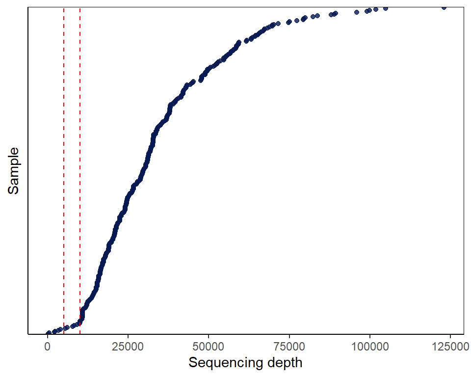

```r
read_counts(colon_asv_tab, line = c(5000,10000))
```

### Sequencing depth

```r
data_filt <- seq_depth_filtering(colon_asv_tab,
                                 colon_taxa_tab,
                                 colon_metadata,
                                 seq_depth_threshold = 10000)
```

```
## Removing 43 ASV(s)
```

```r
filt_colon_asv_tab <- data_filt[[1]]; alpha_colon_asv_tab <- filt_colon_asv_tab
filt_colon_taxa_tab <- data_filt[[2]]; alpha_colon_taxa_tab <- filt_colon_taxa_tab
filt_colon_metadata <- data_filt[[3]]; alpha_colon_metadata <- filt_colon_metadata

seq_step <- dim(filt_colon_asv_tab)[1]
```

Library size

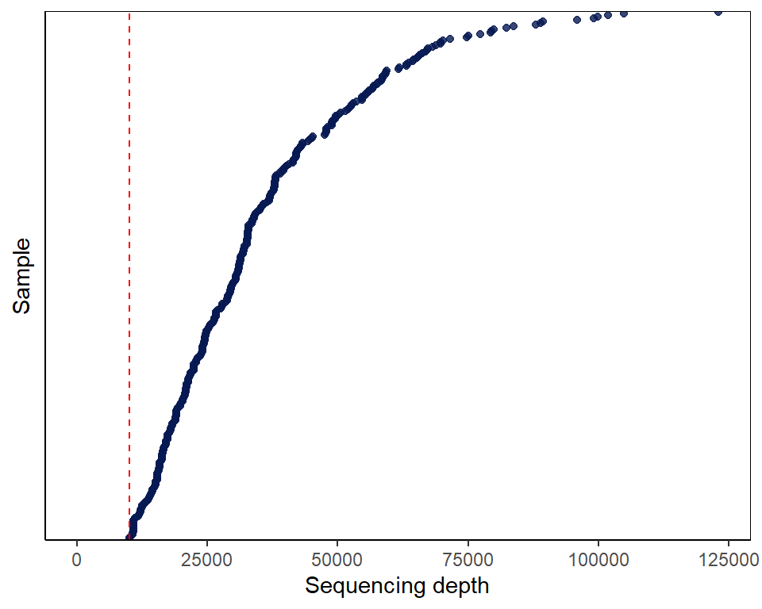

```r
read_counts(filt_colon_asv_tab,line = c(10000))
```

### NearZeroVar

```r
data_filt <- nearzerovar_filtering(filt_colon_asv_tab,
                                   filt_colon_taxa_tab,
                                   filt_colon_metadata)

filt_colon_asv_tab <- data_filt[[1]]
filt_colon_taxa_tab <- data_filt[[2]]
nearzero_step <- dim(filt_colon_asv_tab)[1]
```

Library size

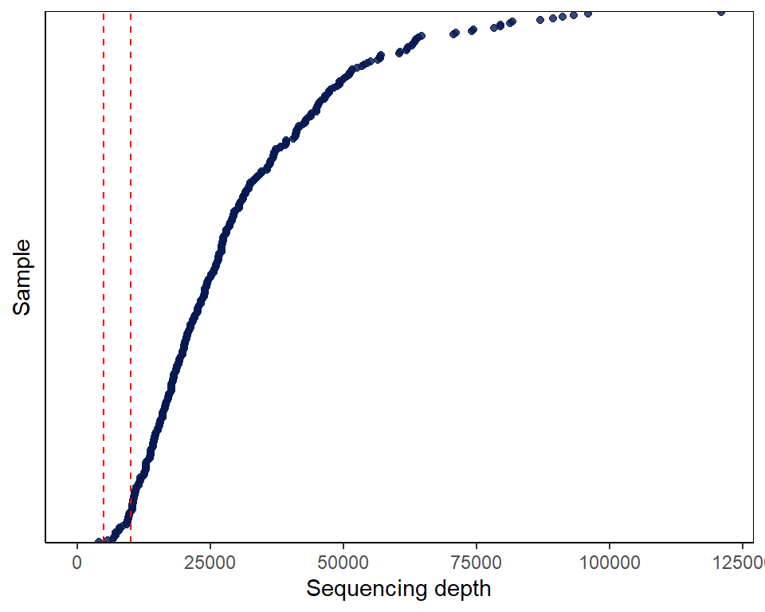

```r
read_counts(filt_colon_asv_tab,line = c(5000,10000))
```

Check zero depth

```r
data_filt <- check_zero_depth(filt_colon_asv_tab,
                              filt_colon_taxa_tab,
                              filt_colon_metadata)

filt_colon_asv_tab <- data_filt[[1]];
filt_colon_taxa_tab <- data_filt[[2]];
filt_colon_metadata <- data_filt[[3]];
```

Library size

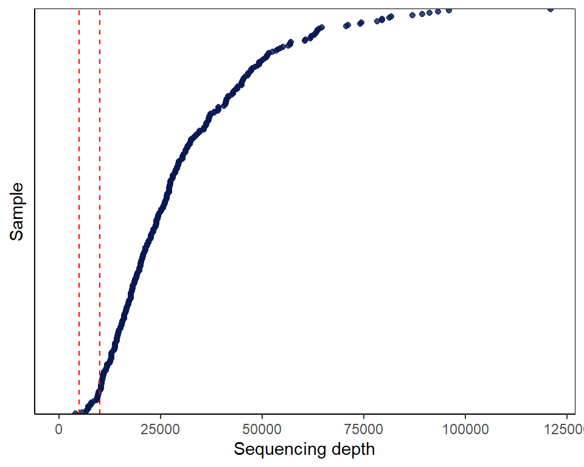

```r
read_counts(filt_colon_asv_tab,line = c(5000,10000))
```

### Final Counts

```r
final_counts_filtering(colon_asv_tab,
                       filt_colon_asv_tab,
                       filt_colon_metadata,
                       seq_step, 0, nearzero_step)
```

|  | V1 |
| --- | --- |
| Raw data: ASVs | 4084 |
| Raw data: Samples | 350 |
| Sequencing depth filt: ASVs | 4041 |
| Prevalence filt: ASVs | 0 |
| NearZeroVar filt: ASVs | 354 |
| Filt data: ASVs | 354 |
| Filt data: Samples | 337 |
| Filt data: Patients | 143 |
| Filt data: Patients.1 | 0 |
| Filtered samples | 13 |

[output cut: 7 more lines]

## Alpha diversity

```r
path = "../results/Q3/alpha_diversity"
```

**Calculation**

```r
# Construct MPSE object
alpha_colon_metadata$Sample <- alpha_colon_metadata$SampleID
colon_mpse <- as.MPSE(construct_phyloseq(alpha_colon_asv_tab,
                                         alpha_colon_taxa_tab,
                                         alpha_colon_metadata))

colon_mpse %<>% mp_rrarefy(raresize = 10000,seed = 123)

# Calculate alpha diversity - rarefied counts
colon_mpse %<>% mp_cal_alpha(.abundance=RareAbundance, force=TRUE)
```

```r
alpha_data <- data.frame(SampleID=colon_mpse$Sample.x,
                         Observe=colon_mpse$Observe,
                         Shannon=colon_mpse$Shannon,
                         Simpson=colon_mpse$Simpson,
                         Pielou=colon_mpse$Pielou,
                         Group=colon_mpse$Group,
                         Country=colon_mpse$Country,
                         Patient=colon_mpse$Patient)

write.csv(alpha_data,file.path(path,paste0("alpha_indices_",segment,".csv")),
          row.names = FALSE)
```

### Plots

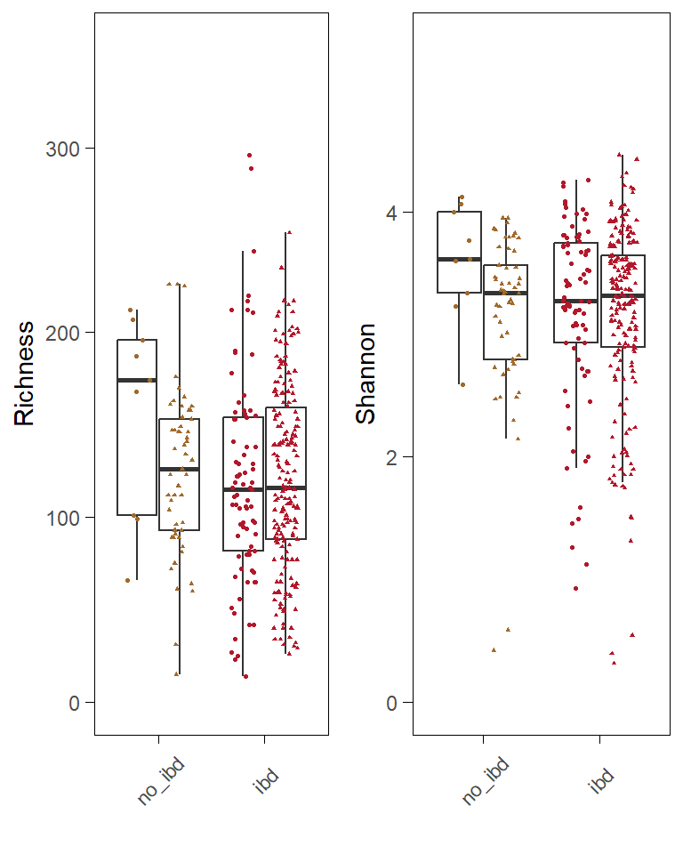

```r
p_boxplot_alpha <- alpha_diversity_countries(alpha_data)
# save the results
alpha_div_plots[[paste(segment,"Country")]] <- p_boxplot_alpha

# see the results
p_boxplot_alpha
```

### Linear Model

```r
path = "../results/Q3/alpha_diversity"
alpha_data <- read.csv(file.path(path,paste0("alpha_indices_",segment,".csv")))
```

**Richness**

```r
results_model <- pairwise.lmer(
  formula = "Observe ~ Group * Country + (1|Patient)",
  factors=alpha_data$Group,
  data=alpha_data)

# check interaction
if (!is.data.frame(results_model)){
  results_model_observe <- results_model[[1]]
  results_model_observe_detailed <- results_model[[2]]
} else {
  results_model_observe <- results_model
  results_model_observe_detailed <- NA
}

# save the results
pc_observed[[segment]] <- results_model_observe
```

```r
# see the results
knitr::kable(results_model_observe,digits = 3,
caption = "Raw results of linear model of richness estimation.")
```

Raw results of linear model of richness estimation.

|  | Estimate | Std..Error | df | t.value | Pr…t.. | p.adj | sig |
| --- | --- | --- | --- | --- | --- | --- | --- |
| no_ibd vs Groupibd | 0.195 | 13.828 | 330.245 | 0.014 | 0.989 | 0.989 |  |
| no_ibd vs ibd - CZ vs NO | -0.556 | 18.199 | 238.733 | -0.031 | 0.976 | 0.976 |  |
| no_ibd vs Groupibd:CountryNO | -1.880 | 18.971 | 263.174 | -0.099 | 0.921 | 0.921 |  |

```r
knitr::kable(results_model_observe_detailed,digits = 3,
caption = "Raw results of independent country analysis")
```

Table: Raw results of independent country analysis

**Shannon**

```r
results_model <- pairwise.lmer(
  formula = "Shannon ~ Group * Country + (1|Patient)",
  factors=alpha_data$Group,
  data=alpha_data)

# check interaction
if (!is.data.frame(results_model)){
  results_model_shannon <- results_model[[1]]
  results_model_shannon_detailed <- results_model[[2]]
} else {
  results_model_shannon <- results_model
  results_model_shannon_detailed <- NA
}

# save the results
pc_shannon[[segment]] <- as.data.frame(results_model_shannon)
```

```r
# see the results
knitr::kable(results_model_shannon,digits = 3,
caption = "Raw results of linear model of Shannon estimation.")
```

Raw results of linear model of Shannon estimation.

|  | Estimate | Std..Error | df | t.value | Pr…t.. | p.adj | sig |
| --- | --- | --- | --- | --- | --- | --- | --- |
| no_ibd vs Groupibd | -0.038 | 0.204 | 332.621 | -0.185 | 0.854 | 0.854 |  |
| no_ibd vs ibd - CZ vs NO | -0.139 | 0.262 | 239.592 | -0.529 | 0.597 | 0.597 |  |
| no_ibd vs Groupibd:CountryNO | 0.101 | 0.275 | 262.547 | 0.367 | 0.714 | 0.714 |  |

```r
knitr::kable(results_model_shannon_detailed,digits = 3,
caption = "Raw results of independent country analysis")
```

Table: Raw results of independent country analysis

**Simpson**

```r
results_model <- pairwise.lmer(
  formula = "Simpson ~ Group * Country + (1|Patient)",
  factors=alpha_data$Group,
  data=alpha_data)

# check interaction
if (!is.data.frame(results_model)){
  results_model_simpson <- results_model[[1]]
  results_model_simpson_detailed <- results_model[[2]]
} else {
  results_model_simpson <- results_model
  results_model_simpson_detailed <- NA
}

# save the results
pc_simpson[[segment]] <- as.data.frame(results_model_simpson)
```

```r
# see the results
knitr::kable(results_model_simpson,digits = 3,
caption = "Raw results of linear model of Simpson estimation.")
```

Raw results of linear model of Simpson estimation.

|  | Estimate | Std..Error | df | t.value | Pr…t.. | p.adj | sig |
| --- | --- | --- | --- | --- | --- | --- | --- |
| no_ibd vs Groupibd | -0.015 | 0.033 | 332.974 | -0.447 | 0.656 | 0.656 |  |
| no_ibd vs ibd - CZ vs NO | -0.036 | 0.042 | 240.107 | -0.860 | 0.391 | 0.391 |  |
| no_ibd vs Groupibd:CountryNO | 0.035 | 0.044 | 261.852 | 0.797 | 0.426 | 0.426 |  |

```r
knitr::kable(results_model_simpson_detailed,digits = 3,
caption = "Raw results of independent country analysis")
```

Table: Raw results of independent country analysis

**Pielou**

```r
results_model <- pairwise.lmer(
  formula = "Pielou ~ Group * Country + (1|Patient)",
  factors=alpha_data$Group,
  data=alpha_data)

# check interaction
if (!is.data.frame(results_model)){
  results_model_pielou <- results_model[[1]]
  results_model_pielou_detailed <- results_model[[2]]
} else {
  results_model_pielou <- results_model
  results_model_pielou_detailed <- NA
}

# save the results
pc_pielou[[segment]] <- as.data.frame(results_model_pielou)
```

```r
# see the results
knitr::kable(results_model_pielou,digits = 3,
caption = "Raw results of linear model of Pielou estimation.")
```

Raw results of linear model of Pielou estimation.

|  | Estimate | Std..Error | df | t.value | Pr…t.. | p.adj | sig |
| --- | --- | --- | --- | --- | --- | --- | --- |
| no_ibd vs Groupibd | -0.009 | 0.034 | 322.353 | -0.263 | 0.792 | 0.792 |  |
| no_ibd vs ibd - CZ vs NO | -0.038 | 0.042 | 233.660 | -0.905 | 0.366 | 0.366 |  |
| no_ibd vs Groupibd:CountryNO | 0.028 | 0.044 | 250.924 | 0.645 | 0.520 | 0.520 |  |

```r
knitr::kable(results_model_pielou_detailed,digits = 3,
caption = "Raw results of independent country analysis")
```

Table: Raw results of independent country analysis

### Saving results

```r
alpha_list <- list(
  Richness=pc_observed[[segment]] %>% rownames_to_column("Comparison"),
  Shannon=pc_shannon[[segment]] %>% rownames_to_column("Comparison"),
  Simpson=pc_simpson[[segment]] %>% rownames_to_column("Comparison"),
  Pielou=pc_pielou[[segment]] %>% rownames_to_column("Comparison"))

write.xlsx(alpha_list,
           file = file.path(path,paste0("alpha_diversity_results_",segment,".xlsx")))
```

## Beta diversity

Calculating Aitchison distance (euclidean distance on clr-transformed data), both at ASV and genus level.

### Main analysis - Genus, Aitchison

**Genus level, Aitchison distance**

```r
level="genus"
```

```r
path = "../results/Q3/beta_diversity"
```

Aggregation, filtering

```r
genus_data <- aggregate_taxa(colon_asv_tab,
                             colon_taxa_tab,
                             taxonomic_level=level,
                             names=TRUE)

filt_data <- filtering_steps(genus_data[[1]],
                             genus_data[[2]],
                             colon_metadata,
                            seq_depth_threshold=10000)
```

```
## Removing 7 ASV(s)
```

```r
filt_colon_genus_tab <- filt_data[[1]]
filt_colon_genus_taxa <- filt_data[[2]]
filt_colon_genus_metadata <- filt_data[[3]]
```

##### PERMANOVA

```r
pairwise_df <- filt_colon_genus_tab %>% column_to_rownames("SeqID") %>% t()

# main effect
pp_main <- pairwise.adonis(pairwise_df,filt_colon_genus_metadata$Group,
                           covariate = filt_colon_genus_metadata$Country,
                           patients = filt_colon_genus_metadata$Patient,
                           sim.method = "robust.aitchison", p.adjust.m="BH")

# interaction
pp_int <- pairwise.adonis(pairwise_df,filt_colon_genus_metadata$Group,
                          covariate = filt_colon_genus_metadata$Country,
                          interaction = TRUE,
                          patients = filt_colon_genus_metadata$Patient,
                          sim.method = "robust.aitchison", p.adjust.m="BH")

# tidy the results
pp_factor <- pp_main[[1]]
pp_cov <- pp_main[[2]]
pp_fac.cov <- pp_int[[3]]

cols <- c("pairs","Df","SumsOfSqs", "F.Model","R2","p.value", "p.adjusted", "sig")
colnames(pp_factor) <- cols; colnames(pp_cov) <- cols; colnames(pp_fac.cov) <- cols;

# save raw results
pairwise_aitchison_raw[[paste(level, segment)]] <-rbind(pp_factor,pp_cov,pp_fac.cov)
```

```r
# see the results
knitr::kable(pp_factor,digits = 3,caption = "PERMANOVA, GROUP separation")
```

PERMANOVA, GROUP separation

| pairs | Df | SumsOfSqs | F.Model | R2 | p.value | p.adjusted | sig |
| --- | --- | --- | --- | --- | --- | --- | --- |
| no_ibd vs ibd | 1 | 170.678 | 1.097 | 0.003 | 1 | 1 |  |

```r
knitr::kable(pp_cov,digits = 3,caption = "PERMANOVA, COUNTRY separation")
```

PERMANOVA, COUNTRY separation

| pairs | Df | SumsOfSqs | F.Model | R2 | p.value | p.adjusted | sig |
| --- | --- | --- | --- | --- | --- | --- | --- |
| no_ibd vs ibd , Country | 1 | 396.369 | 2.547 | 0.008 | 0.169 | 0.169 |  |

```r
knitr::kable(pp_fac.cov,digits = 3,caption = "PERMANOVA, INTERACTION GROUP:Country")
```

PERMANOVA, INTERACTION GROUP:Country

| pairs | Df | SumsOfSqs | F.Model | R2 | p.value | p.adjusted | sig |
| --- | --- | --- | --- | --- | --- | --- | --- |
| no_ibd vs ibd : Country | 1 | 133.144 | 0.855 | 0.003 | 0.999 | 0.999 |  |

Interaction check

```r
interaction_sig <- pp_fac.cov$pairs[pp_fac.cov$p.adjusted < 0.1]

if (length(interaction_sig)>0){
 for (i in 1:length(interaction_sig)){
  group1 <- unlist(strsplit(interaction_sig[i],split = " vs "))[1]
  group2 <- unlist(strsplit(interaction_sig[i],split = " vs "))[2]
  group2 <- unlist(strsplit(group2,split = " : "))[1]

  result_list <- adonis_postanalysis(x=pairwise_df,
                      factors = filt_colon_genus_metadata$Group,
                      covariate = filt_colon_genus_metadata$Country,
                      group1 = group1,
                      group2 = group2,
                      patients = filt_colon_genus_metadata$Patient)
  print(result_list)
}
}
```

##### Plots

**PCoA custom**

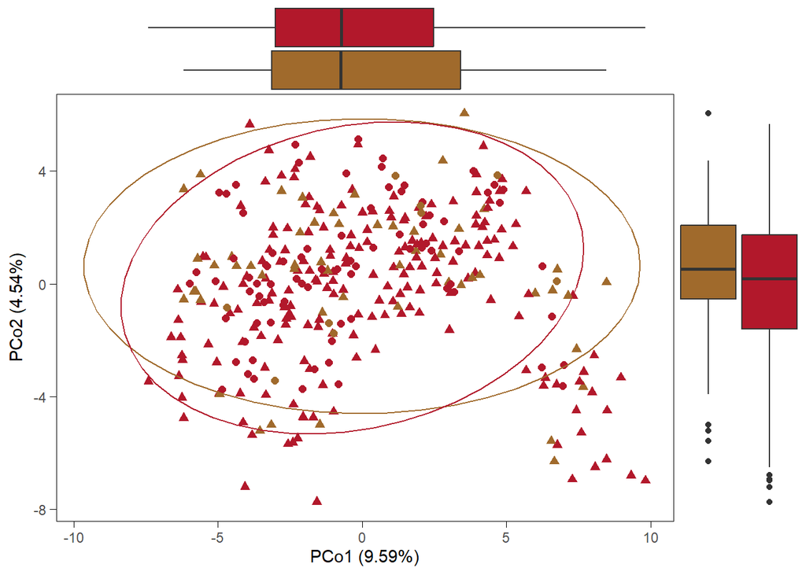

```r
p <- pca_plot_custom(filt_colon_genus_tab,
                                 filt_colon_genus_taxa,
                                 filt_colon_genus_metadata,
                                 show_boxplots = TRUE,
                                 variable = "Group", size=2,
                                 show_legend=FALSE)

# save the results
pca_plots_list[[paste(segment,level,"custom")]] <- p

# see the results
p
```

#### Saving results

```r
write.xlsx(pairwise_aitchison_raw[[paste(level, segment)]],
           file = file.path(path,
           paste0("beta_diversity_results_", segment,".xlsx")))
```

### Supplementary analysis

#### Genus level

```r
level="genus"
```

##### Bray-Curtis

**PERMANOVA**

```r
pairwise_df <- filt_colon_genus_tab %>% column_to_rownames("SeqID") %>% t()

# main effect
pp_main <- pairwise.adonis(pairwise_df,
                           filt_colon_genus_metadata$Group,
                           covariate = filt_colon_genus_metadata$Country,
                           patients = filt_colon_genus_metadata$Patient,
                           sim.method = "bray", p.adjust.m="BH")

# interaction
pp_int <- pairwise.adonis(pairwise_df,
                          filt_colon_genus_metadata$Group,
                          covariate = filt_colon_genus_metadata$Country,
                          patients = filt_colon_genus_metadata$Patient,
                          interaction = TRUE, sim.method = "bray", p.adjust.m="BH")

# tidy the results
pp_factor <- pp_main[[1]]
pp_cov <- pp_main[[2]]
pp_fac.cov <- pp_int[[3]]

cols <- c("pairs","Df","SumsOfSqs", "F.Model","R2","p.value", "p.adjusted", "sig")
colnames(pp_factor) <- cols; colnames(pp_cov) <- cols; colnames(pp_fac.cov) <- cols;

# save raw results
supplements_beta[[paste("bray",level,segment)]] <- rbind(pp_factor,pp_cov,pp_fac.cov)
```

```r
# see the results
knitr::kable(pp_factor,digits = 3,caption = "PERMANOVA, GROUP separation")
```

PERMANOVA, GROUP separation

| pairs | Df | SumsOfSqs | F.Model | R2 | p.value | p.adjusted | sig |
| --- | --- | --- | --- | --- | --- | --- | --- |
| no_ibd vs ibd | 1 | 0.26 | 1.088 | 0.003 | 0.988 | 0.988 |  |

```r
knitr::kable(pp_cov,digits = 3,caption = "PERMANOVA, COUNTRY separation")
```

PERMANOVA, COUNTRY separation

| pairs | Df | SumsOfSqs | F.Model | R2 | p.value | p.adjusted | sig |
| --- | --- | --- | --- | --- | --- | --- | --- |
| no_ibd vs ibd , Country | 1 | 0.839 | 3.515 | 0.01 | 0.095 | 0.095 |  |

```r
knitr::kable(pp_fac.cov,digits = 3,caption = "PERMANOVA, INTERACTION GROUP:Country")
```

PERMANOVA, INTERACTION GROUP:Country

| pairs | Df | SumsOfSqs | F.Model | R2 | p.value | p.adjusted | sig |
| --- | --- | --- | --- | --- | --- | --- | --- |
| no_ibd vs ibd : Country | 1 | 0.164 | 0.686 | 0.002 | 0.998 | 0.998 |  |

Interaction check

```r
interaction_sig <- pp_fac.cov$pairs[pp_fac.cov$p.adjusted < 0.05]

if (length(interaction_sig)>0){
for (i in 1:length(interaction_sig)){
  group1 <- unlist(strsplit(interaction_sig[i],split = " vs "))[1]
  group2 <- unlist(strsplit(interaction_sig[i],split = " vs "))[2]
  group2 <- unlist(strsplit(group2,split = " : "))[1]

  result_list <- adonis_postanalysis(x=pairwise_df,
                      factors = filt_colon_genus_metadata$Group,
                      covariate = filt_colon_genus_metadata$Country,
                      patients = filt_colon_genus_metadata$Patient,
                      group1 = group1,
                      group2 = group2,
                      sim.method = 'bray')
  print(result_list)
}
}
```

**Plots**

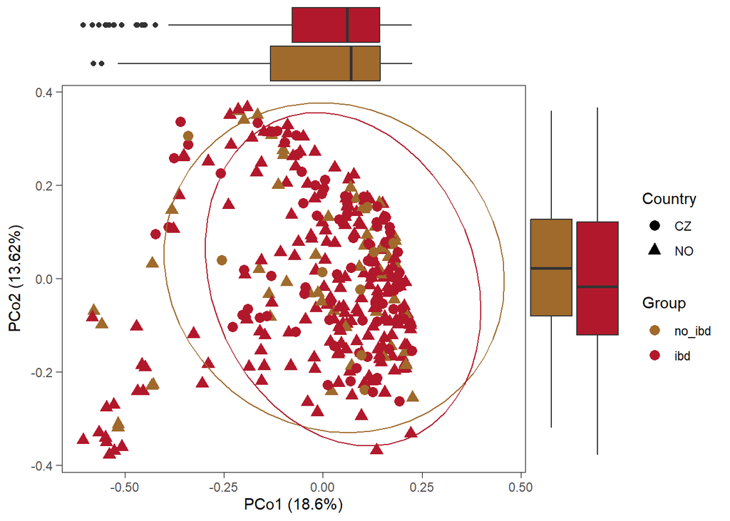

```r
p <- pca_plot_custom(filt_colon_genus_tab,
                                 filt_colon_genus_taxa,
                                 filt_colon_genus_metadata,
                                 measure = "bray",
                                 show_boxplots = TRUE,
                                 variable = "Group", size=3, show_legend=TRUE)

# save the results
supplements_beta[[paste("PCoA bray",level,segment)]] <- p

# see the results
p
```

##### Jaccard

**PERMANOVA**

```r
pairwise_df <- filt_colon_genus_tab %>% column_to_rownames("SeqID") %>% t()

# main effect
pp_main <- pairwise.adonis(pairwise_df,
                           filt_colon_genus_metadata$Group,
                           covariate = filt_colon_genus_metadata$Country,
                           patients = filt_colon_genus_metadata$Patient,
                           sim.method = "jaccard", p.adjust.m="BH")

# interaction
pp_int <- pairwise.adonis(pairwise_df,
                          filt_colon_genus_metadata$Group,
                          covariate = filt_colon_genus_metadata$Country,
                          patients = filt_colon_genus_metadata$Patient,
                          interaction = TRUE, sim.method = "jaccard", p.adjust.m="BH")

# tidy the results
pp_factor <- pp_main[[1]]
pp_cov <- pp_main[[2]]
pp_fac.cov <- pp_int[[3]]

cols <- c("pairs","Df","SumsOfSqs", "F.Model","R2","p.value", "p.adjusted", "sig")
colnames(pp_factor) <- cols; colnames(pp_cov) <- cols; colnames(pp_fac.cov) <- cols;

# save raw results
supplements_beta[[paste("jaccard",level,segment)]] <- rbind(pp_factor,
                                                            pp_cov,
                                                            pp_fac.cov)
```

```r
# see the results
knitr::kable(pp_factor,digits = 3,caption = "PERMANOVA, GROUP separation")
```

PERMANOVA, GROUP separation

| pairs | Df | SumsOfSqs | F.Model | R2 | p.value | p.adjusted | sig |
| --- | --- | --- | --- | --- | --- | --- | --- |
| no_ibd vs ibd | 1 | 0.354 | 1.107 | 0.003 | 1 | 1 |  |

```r
knitr::kable(pp_cov,digits = 3,caption = "PERMANOVA, COUNTRY separation")
```

PERMANOVA, COUNTRY separation

| pairs | Df | SumsOfSqs | F.Model | R2 | p.value | p.adjusted | sig |
| --- | --- | --- | --- | --- | --- | --- | --- |
| no_ibd vs ibd , Country | 1 | 0.9 | 2.814 | 0.008 | 0.138 | 0.138 |  |

```r
knitr::kable(pp_fac.cov,digits = 3,caption = "PERMANOVA, INTERACTION GROUP:Country")
```

PERMANOVA, INTERACTION GROUP:Country

| pairs | Df | SumsOfSqs | F.Model | R2 | p.value | p.adjusted | sig |
| --- | --- | --- | --- | --- | --- | --- | --- |
| no_ibd vs ibd : Country | 1 | 0.252 | 0.787 | 0.002 | 1 | 1 |  |

Interaction check

```r
interaction_sig <- pp_fac.cov$pairs[pp_fac.cov$p.adjusted < 0.05]

if (length(interaction_sig)>0){
for (i in 1:length(interaction_sig)){
  group1 <- unlist(strsplit(interaction_sig[i],split = " vs "))[1]
  group2 <- unlist(strsplit(interaction_sig[i],split = " vs "))[2]
  group2 <- unlist(strsplit(group2,split = " : "))[1]

  result_list <- adonis_postanalysis(x=pairwise_df,
                      factors = filt_colon_genus_metadata$Group,
                      covariate = filt_colon_genus_metadata$Country,
                      patients = filt_colon_genus_metadata$Patient,
                      group1 = group1,
                      group2 = group2,
                      sim.method = 'jaccard')
  print(result_list)
}
}
```

**Plots**

*Custom*

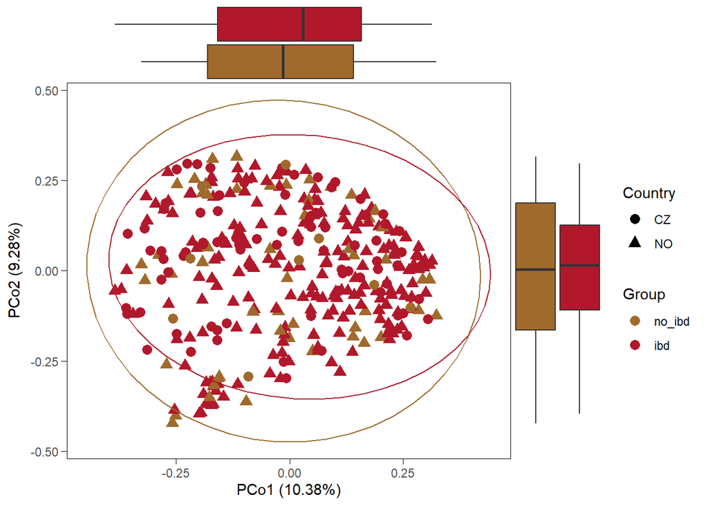

```r
p <- pca_plot_custom(filt_colon_genus_tab,
                                 filt_colon_genus_taxa,
                                 filt_colon_genus_metadata,
                                 measure = "jaccard",
                                 show_boxplots = TRUE,
                                 variable = "Group", size=3, show_legend=TRUE)

# save the results
supplements_beta[[paste("PCoA jaccard",level,segment)]] <- p

# see the results
p
```

#### ASV level

```r
level="ASV"
```

##### Aitchison

```r
# preparing data frame
pairwise_df <- filt_colon_asv_tab %>% column_to_rownames("SeqID") %>% t()

# main effect
pp_main <- pairwise.adonis(x=pairwise_df,
                          filt_colon_metadata$Group,
                           covariate = filt_colon_metadata$Country,
                           sim.method = "robust.aitchison",
                           p.adjust.m="BH",
                           patients = filt_colon_metadata$Patient)

# interaction
pp_int <- pairwise.adonis(pairwise_df,filt_colon_metadata$Group,
                          covariate = filt_colon_metadata$Country,
                          interaction = TRUE,
                          sim.method = "robust.aitchison",
                          p.adjust.m="BH",
                          patients = filt_colon_metadata$Patient)

pp_factor <- pp_main[[1]]
pp_cov <- pp_main[[2]]
pp_fac.cov <- pp_int[[3]]

cols <- c("pairs","Df","SumsOfSqs", "F.Model","R2","p.value", "p.adjusted", "sig")
colnames(pp_factor) <- cols; colnames(pp_cov) <- cols; colnames(pp_fac.cov) <- cols;

# save raw results
supplements_beta[[paste("aitchison",level,segment)]] <- rbind(pp_factor,
                                                            pp_cov,
                                                            pp_fac.cov)

# see the results
pp_factor
```

| pairs | Df | SumsOfSqs | F.Model | R2 | p.value | p.adjusted | sig |
| --- | --- | --- | --- | --- | --- | --- | --- |
| no_ibd vs ibd | 1 | 277.6939 | 1.230133 | 0.003644541 | 1 | 1 |  |

```r
pp_cov
```

| pairs | Df | SumsOfSqs | F.Model | R2 | p.value | p.adjusted | sig |
| --- | --- | --- | --- | --- | --- | --- | --- |
| no_ibd vs ibd , Country | 1 | 521.5549 | 2.310392 | 0.006845048 | 0.173 | 0.173 |  |

```r
pp_fac.cov
```

| pairs | Df | SumsOfSqs | F.Model | R2 | p.value | p.adjusted | sig |
| --- | --- | --- | --- | --- | --- | --- | --- |
| no_ibd vs ibd : Country | 1 | 184.5627 | 0.8171312 | 0.002422258 | 1 | 1 |  |

```r
# see the results
knitr::kable(pp_factor,digits = 3,caption = "PERMANOVA, GROUP separation")
```

PERMANOVA, GROUP separation

| pairs | Df | SumsOfSqs | F.Model | R2 | p.value | p.adjusted | sig |
| --- | --- | --- | --- | --- | --- | --- | --- |
| no_ibd vs ibd | 1 | 277.694 | 1.23 | 0.004 | 1 | 1 |  |

```r
knitr::kable(pp_cov,digits = 3,caption = "PERMANOVA, COUNTRY separation")
```

PERMANOVA, COUNTRY separation

| pairs | Df | SumsOfSqs | F.Model | R2 | p.value | p.adjusted | sig |
| --- | --- | --- | --- | --- | --- | --- | --- |
| no_ibd vs ibd , Country | 1 | 521.555 | 2.31 | 0.007 | 0.173 | 0.173 |  |

```r
knitr::kable(pp_fac.cov,digits = 3,caption = "PERMANOVA, INTERACTION GROUP:Country")
```

PERMANOVA, INTERACTION GROUP:Country

| pairs | Df | SumsOfSqs | F.Model | R2 | p.value | p.adjusted | sig |
| --- | --- | --- | --- | --- | --- | --- | --- |
| no_ibd vs ibd : Country | 1 | 184.563 | 0.817 | 0.002 | 1 | 1 |  |

Interaction check

```r
interaction_sig <- pp_fac.cov$pairs[pp_fac.cov$p.adjusted < 0.05]

if (length(interaction_sig)>0){
 for (i in 1:length(interaction_sig)){
  group1 <- unlist(strsplit(interaction_sig[i],split = " vs "))[1]
  group2 <- unlist(strsplit(interaction_sig[i],split = " vs "))[2]
  group2 <- unlist(strsplit(group2,split = " : "))[1]

  result_list <- adonis_postanalysis(x=pairwise_df,
                      factors = filt_colon_metadata$Group,
                      covariate = filt_colon_metadata$Country,
                      group1 = group1,
                      group2 = group2,
                      patients = filt_colon_metadata$Patient)
  print(result_list)
}
}
```

**PCoA**

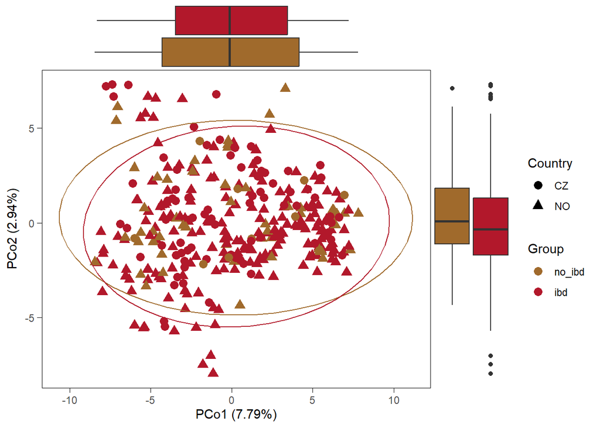

```r
p <- pca_plot_custom(filt_colon_asv_tab,
                           filt_colon_taxa_tab,
                           filt_colon_metadata,
                           show_boxplots = TRUE,
                           variable = "Group",
                           size=3,
                           show_legend=TRUE)

# save the results
supplements_beta[[paste("PCoA aitchison",level,segment)]] <- p

# see the results
p
```

##### Bray-Curtis

**PERMANOVA**

```r
# preparing data frame
pairwise_df <- filt_colon_asv_tab %>% column_to_rownames("SeqID") %>% t()

# main effect
pp_main <- pairwise.adonis(pairwise_df,
                           filt_colon_metadata$Group,
                           covariate = filt_colon_metadata$Country,
                           patients = filt_colon_metadata$Patient,
                           sim.method = "bray", p.adjust.m="BH")

# interaction
pp_int <- pairwise.adonis(pairwise_df,
                          filt_colon_metadata$Group,
                          covariate = filt_colon_metadata$Country,
                          patients = filt_colon_metadata$Patient,
                          interaction = TRUE, sim.method = "bray", p.adjust.m="BH")

pp_factor <- pp_main[[1]]
pp_cov <- pp_main[[2]]
pp_fac.cov <- pp_int[[3]]

cols <- c("pairs","Df","SumsOfSqs", "F.Model","R2","p.value", "p.adjusted", "sig")
colnames(pp_factor) <- cols; colnames(pp_cov) <- cols; colnames(pp_fac.cov) <- cols;

# save raw results
supplements_beta[[paste("bray",level,segment)]] <- rbind(pp_factor,
                                                            pp_cov,
                                                            pp_fac.cov)
```

```r
# see the results
knitr::kable(pp_factor,digits = 3,caption = "PERMANOVA, GROUP separation")
```

PERMANOVA, GROUP separation

| pairs | Df | SumsOfSqs | F.Model | R2 | p.value | p.adjusted | sig |
| --- | --- | --- | --- | --- | --- | --- | --- |
| no_ibd vs ibd | 1 | 0.481 | 1.36 | 0.004 | 0.994 | 0.994 |  |

```r
knitr::kable(pp_cov,digits = 3,caption = "PERMANOVA, COUNTRY separation")
```

PERMANOVA, COUNTRY separation

| pairs | Df | SumsOfSqs | F.Model | R2 | p.value | p.adjusted | sig |
| --- | --- | --- | --- | --- | --- | --- | --- |
| no_ibd vs ibd , Country | 1 | 0.989 | 2.794 | 0.008 | 0.152 | 0.152 |  |

```r
knitr::kable(pp_fac.cov,digits = 3,caption = "PERMANOVA, INTERACTION GROUP:Country")
```

PERMANOVA, INTERACTION GROUP:Country

| pairs | Df | SumsOfSqs | F.Model | R2 | p.value | p.adjusted | sig |
| --- | --- | --- | --- | --- | --- | --- | --- |
| no_ibd vs ibd : Country | 1 | 0.265 | 0.749 | 0.002 | 1 | 1 |  |

Interaction check

```r
interaction_sig <- pp_fac.cov$pairs[pp_fac.cov$p.adjusted < 0.05]

if (length(interaction_sig)>0){
for (i in 1:length(interaction_sig)){
  group1 <- unlist(strsplit(interaction_sig[i],split = " vs "))[1]
  group2 <- unlist(strsplit(interaction_sig[i],split = " vs "))[2]
  group2 <- unlist(strsplit(group2,split = " : "))[1]

  result_list <- adonis_postanalysis(x=pairwise_df,
                      factors = filt_colon_metadata$Group,
                      covariate = filt_colon_metadata$Country,
                      group1 = group1,
                      group2 = group2,
                      patients = filt_colon_metadata$Patient,
                      sim.method = 'bray')
  print(result_list)
}
}
```

**PCoA**

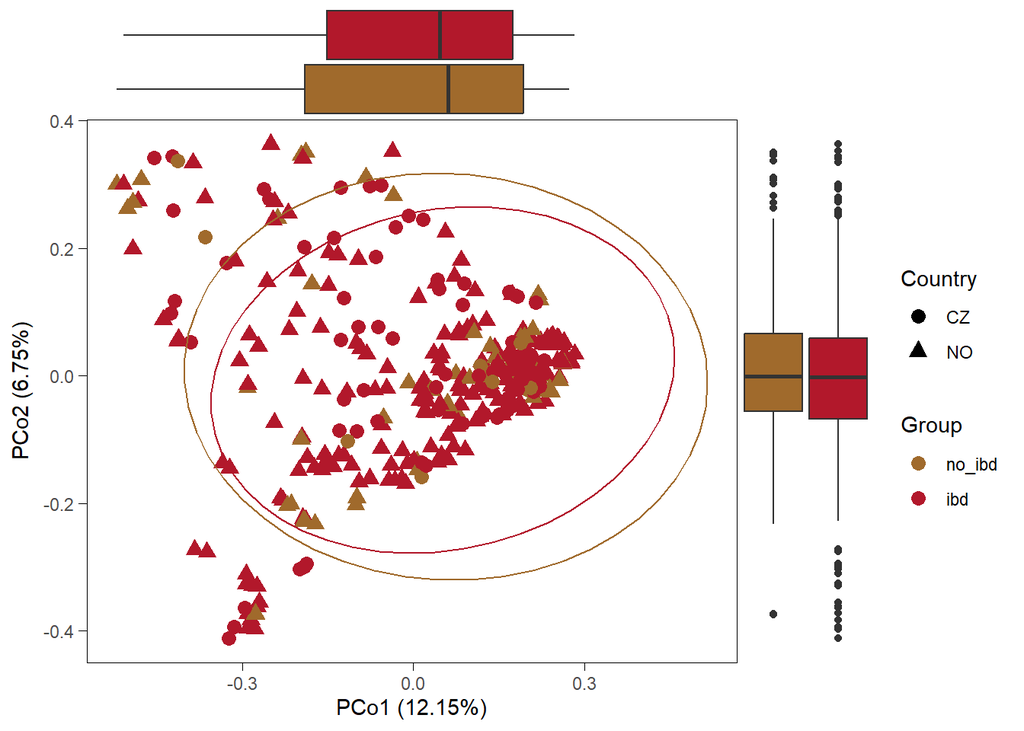

```r
p <- pca_plot_custom(filt_colon_asv_tab,
                     filt_colon_taxa_tab,
                     filt_colon_metadata,
                     measure = "bray",
                     show_boxplots = TRUE,
                     variable = "Group", size=3, show_legend=TRUE)

# save the results
supplements_beta[[paste("PCoA bray",level,segment)]] <- p

# see the results
p
```

##### Jaccard

**PERMANOVA**

```r
# preparing data frame
pairwise_df <- filt_colon_asv_tab %>% column_to_rownames("SeqID") %>% t()

# main effect
pp_main <- pairwise.adonis(pairwise_df,
                           filt_colon_metadata$Group,
                           covariate = filt_colon_metadata$Country,
                           patients = filt_colon_metadata$Patient,
                           sim.method = "jaccard", p.adjust.m="BH")

# interaction
pp_int <- pairwise.adonis(pairwise_df,
                          filt_colon_metadata$Group,
                          covariate = filt_colon_metadata$Country,
                          patients = filt_colon_metadata$Patient,
                          interaction = TRUE, sim.method = "jaccard", p.adjust.m="BH")

pp_factor <- pp_main[[1]]
pp_cov <- pp_main[[2]]
pp_fac.cov <- pp_int[[3]]

cols <- c("pairs","Df","SumsOfSqs", "F.Model","R2","p.value", "p.adjusted", "sig")
colnames(pp_factor) <- cols; colnames(pp_cov) <- cols; colnames(pp_fac.cov) <- cols;

# save raw results
supplements_beta[[paste("jaccard",level,segment)]] <- rbind(pp_factor,
                                                            pp_cov,
                                                            pp_fac.cov)
```

```r
# see the results
knitr::kable(pp_factor,digits = 3,caption = "PERMANOVA, GROUP separation")
```

PERMANOVA, GROUP separation

| pairs | Df | SumsOfSqs | F.Model | R2 | p.value | p.adjusted | sig |
| --- | --- | --- | --- | --- | --- | --- | --- |
| no_ibd vs ibd | 1 | 0.53 | 1.288 | 0.004 | 1 | 1 |  |

```r
knitr::kable(pp_cov,digits = 3,caption = "PERMANOVA, COUNTRY separation")
```

PERMANOVA, COUNTRY separation

| pairs | Df | SumsOfSqs | F.Model | R2 | p.value | p.adjusted | sig |
| --- | --- | --- | --- | --- | --- | --- | --- |
| no_ibd vs ibd , Country | 1 | 0.984 | 2.391 | 0.007 | 0.258 | 0.258 |  |

```r
knitr::kable(pp_fac.cov,digits = 3,caption = "PERMANOVA, INTERACTION GROUP:Country")
```

PERMANOVA, INTERACTION GROUP:Country

| pairs | Df | SumsOfSqs | F.Model | R2 | p.value | p.adjusted | sig |
| --- | --- | --- | --- | --- | --- | --- | --- |
| no_ibd vs ibd : Country | 1 | 0.345 | 0.839 | 0.002 | 1 | 1 |  |

Interaction check

```r
interaction_sig <- pp_fac.cov$pairs[pp_fac.cov$p.adjusted < 0.05]

if (length(interaction_sig)>0){
for (i in 1:length(interaction_sig)){
  group1 <- unlist(strsplit(interaction_sig[i],split = " vs "))[1]
  group2 <- unlist(strsplit(interaction_sig[i],split = " vs "))[2]
  group2 <- unlist(strsplit(group2,split = " : "))[1]

  result_list <- adonis_postanalysis(x=pairwise_df,
                      factors = filt_colon_metadata$Group,
                      covariate = filt_colon_metadata$Country,
                      patients = filt_colon_metadata$Patient,
                      group1 = group1,
                      group2 = group2,
                      sim.method = 'jaccard')
  print(result_list)
}
}
```

**PCoA**

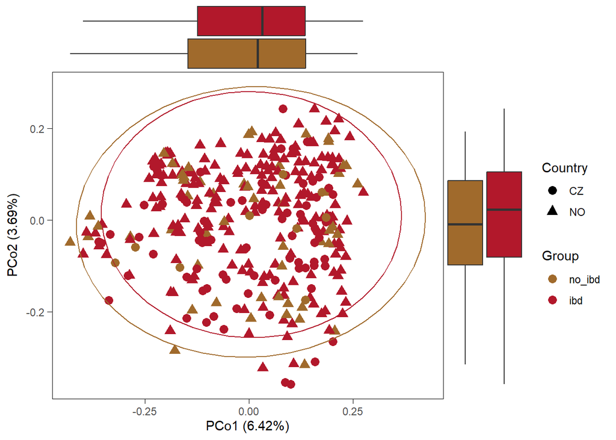

```r
p <- pca_plot_custom(filt_colon_asv_tab,
                     filt_colon_taxa_tab,
                     filt_colon_metadata,
                     measure = "jaccard",
                     show_boxplots = TRUE,
                     variable = "Group", size=3, show_legend=TRUE)

# save the results
supplements_beta[[paste("PCoA jaccard",level,segment)]] <- p

# see the results
p
```

#### Saving results

```r
write.xlsx(supplements_beta[!grepl("PCoA",names(supplements_beta))],
           file = file.path(path,
           paste0("supplements_beta_diversity_", segment,".xlsx")))
```

## Univariate Analysis

### Main - Genus level

```r
level="genus"
```

```r
# needed paths
path = "../results/Q3/univariate_analysis"
path_maaslin=file.path("../intermediate_files/maaslin/Q3",level)
```

```r
# variables
raw_linda_results_genus[[segment]] <- list()
linda_results_genus[[segment]] <- list()

# country and interaction problems
list_intersections <- list()
list_venns <- list()
uni_statistics <- list()

# workbook for final df
wb <- createWorkbook()

# PSC effect
psc_effect <- list()
```

#### Genus level

```r
level="genus"
```

Aggregate taxa

```r
genus_data <- aggregate_taxa(colon_asv_tab,
                             colon_taxa_tab,
                             taxonomic_level = level)

colon_genus_tab <- genus_data[[1]]
colon_genus_taxa_tab <- genus_data[[2]]

colon_genus_asv_taxa_tab <- create_asv_taxa_table(colon_genus_tab,
                                                  colon_genus_taxa_tab)
```

##### ibd vs no_ibd

```r
group <- c("no_ibd","ibd")
comparison_name <- paste0(group[1], " vs ",group[2])
```

###### linda

```r
# prepare the data
linda_data <- binomial_prep(colon_genus_tab,
                            colon_genus_taxa_tab,
                            colon_metadata,
                            group, usage="linDA")
```

```
## Removing 7 ASV(s)
```

```r
filt_colon_uni_data <- linda_data[[1]]
filt_colon_uni_taxa <- linda_data[[2]]
filt_colon_uni_metadata <- linda_data[[3]]

# fit the model
linda.obj <- linda(filt_colon_uni_data,
                   filt_colon_uni_metadata,
                   formula = '~ Group * Country + (1|Patient)')
```

```
## 0  features are filtered!
## The filtered data has  337  samples and  159  features will be tested!
## Imputation approach is used.
## Fit linear mixed effects models ...
## Completed.
```

```r
linda.output <- linda.obj$output
linda.output <- linda_renaming(linda.output, group)

# save the results
group1 <- paste0(group[1], " vs ","Group",group[2])
group2 <- paste0(group[1], " , ",group[2], " - CZ vs NO")
group3 <- paste0(group[1], " vs ","Group",group[2], ":CountryNO")


for (grp in c(group1,group2,group3)){
  raw_linda_results_genus[[segment]][[grp]] <-
    rawlinda.df(linda.output,
                grp,
                filt_colon_uni_data,
                filt_colon_uni_taxa)

  linda_results_genus[[segment]][[grp]] <-
    linda.df(linda.output,
             grp,
             filt_colon_uni_data,
             filt_colon_uni_taxa)
}
```

```r
# volcano plot
volcano_1 <- volcano_plot_linda(linda.output, group1,
                                taxa_table = filt_colon_uni_taxa) +
            ggtitle(paste(group,collapse=" vs "))
```

```
## Using Phylum for naming
```

```r
volcano_2  <- volcano_plot_linda(linda.output, group2,
                                taxa_table = filt_colon_uni_taxa) +
            ggtitle("NO vs CZ")
```

```
## Using Phylum for naming
```

```r
volcano_3 <- volcano_plot_linda(linda.output, group3,
                                taxa_table = filt_colon_uni_taxa) +
            ggtitle("Interaction effect")
```

```
## Using Phylum for naming
```

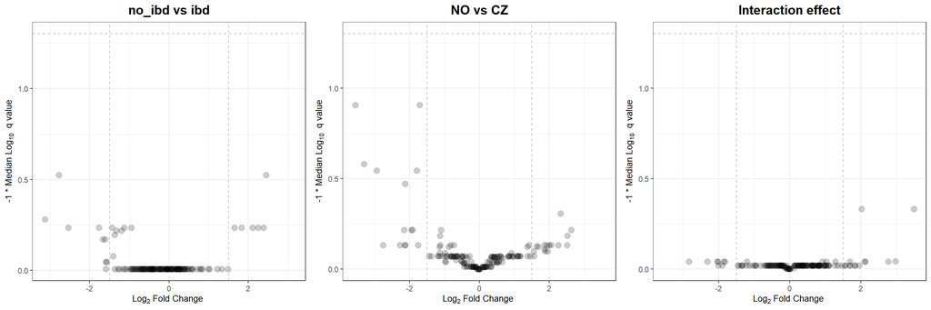

```r
volcano <- ggarrange(volcano_1,volcano_2,volcano_3, ncol=3)

# see the plot
volcano
```

###### MaAsLin2

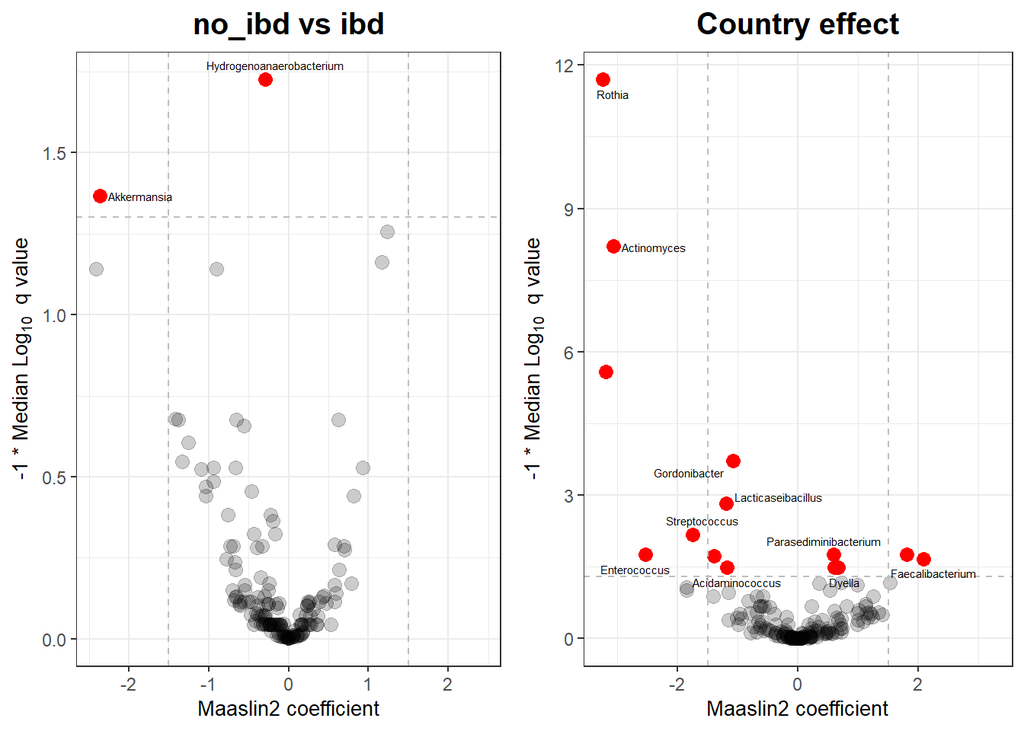

```r
volcano1 <- volcano_plot_maaslin(fit_data,filt_colon_uni_taxa) +
            ggtitle(paste(group[1], "vs", group[2]))

volcano2 <- volcano_plot_maaslin(fit_data,filt_colon_uni_taxa,variable="Country") +
            ggtitle("Country effect")

volcano <- ggarrange(volcano1,volcano2, ncol=2)
volcano
```

###### Group - Intersection

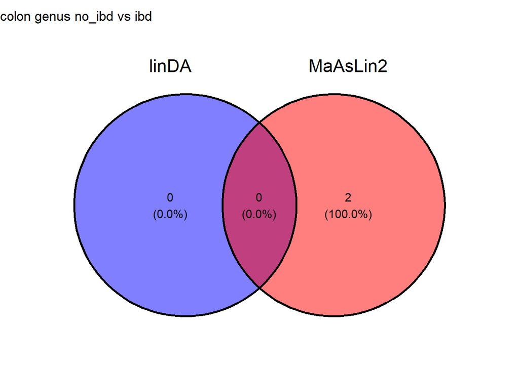

```r
intersection_results <- group_intersection(group, list_intersections, list_venns,
                                           linda.output, fit_data,
                                           raw_linda_results_genus,
                                           segment = segment,
                                           level=level)

list_intersections <- intersection_results[[1]]
list_venns <- intersection_results[[2]]
venn <- intersection_results[[3]]

# show the results
venn
```

###### Interaction effect

```r
list_interaction_significant <- country_interaction(group,
                                                    linda.output,
                                                    list_intersections,
                                          filt_colon_uni_data,
                                          filt_colon_uni_metadata,
                                          segment=segment,
                                          level=level)

# see the result
## significant interaction effect
list_interaction_significant[[1]]
```

```r
## results for czech cohort
list_interaction_significant[[2]]
```

```
## [1] NA
```

```r
## results for norwegian cohort
list_interaction_significant[[3]]
```

```
## [1] NA
```

Removing problematic taxa

```r
list_intersections <- removing_interaction_problems(group,
                                                    list_interaction_significant,
                                                    list_intersections,
                                                    segment=segment,
                                                    level=level)
```

##### Basic statistics

```r
uni_df <-  merge(basic_univariate_statistics(linda_data,group),
                 raw_linda_results_genus[[segment]][[group1]],
                 by="SeqID",all=TRUE)
```

```
## [1] "no_ibd"
## [1] "ibd"
## [1] "no_ibd"
## [1] "ibd"
```

```r
uni_df[["final_sig"]] <- uni_df$SeqID %in% list_intersections[[paste(segment,level,comparison_name)]][["SeqID"]]
uni_statistics[[segment]][[paste(level,comparison_name)]] <- uni_df

# for comparison
new_name <- comparison_name
addWorksheet(wb, sheetName = new_name)
writeData(wb, sheet = new_name, uni_df, rowNames=FALSE)
```

##### Visualization

Heatmap visualizing the linDA’s logFoldChange for taxa with p < 0.1.

```r
list_heatmap <- list_intersections[grep(paste(segment,level),
                                  names(list_intersections),value=TRUE)]
if (length((list_heatmap[[1]][[1]]))>1){
p_heatmap_linda <- heatmap_linda(list_heatmap,colon_taxa_tab)
p_heatmap_linda
}
```

Dot heatmap

```r
if (length((list_heatmap[[1]][[1]]))>0){
dotheatmap_linda <- dot_heatmap_linda(list_heatmap,
                                      uni_statistics$terminal_ileum[grepl(level,names(uni_statistics$terminal_ileum))],
                                      colon_taxa_tab)
dotheatmap_linda
}
```

**Horizontal bar plot**

```r
if (length((list_heatmap[[1]][[1]]))>0){
p_prevalence <- horizontal_barplot(wb,taxa=levels(dotheatmap_linda$data$SeqID))

p_prevalence_final <- ggarrange(p_prevalence,
                                ggplot() + theme_minimal(),
                                nrow = 2,heights = c(1,0.085))
p <- ggarrange(dotheatmap_linda + theme(legend.position = "none"),p_prevalence_final,ncol=2,widths = c(1,0.2))
p
}
```

#### Saving results

```r
# ALL DATA
saveWorkbook(wb,file.path(path,paste0("uni_analysis_wb_",segment,".xlsx")),
             overwrite = TRUE)

# SIGNIFICANT taxa

write.xlsx(list_intersections[grepl(segment,names(list_intersections))] %>%
            `names<-`(gsub(segment, "", names(
              list_intersections[grepl(segment,names(list_intersections))]))),
           file.path(path,paste0("significant_taxa_",segment,".xlsx")))
```

### Supplementary Analysis

#### ASV level

```r
level="ASV"
```

```r
path_maaslin="../intermediate_files/maaslin/Q3/ASV/"
```

```r
raw_linda_results[[segment]] <- list()
linda_results[[segment]] <- list()
supplements_wb <- createWorkbook()
```

##### ibd vs no_ibd

```r
group <- c("no_ibd","ibd")
comparison_name <- paste0(group[1], " vs ",group[2])
```

**linDA**

```r
# prepare the data
linda_data <- binomial_prep(colon_asv_tab,
                            colon_taxa_tab,
                            colon_metadata,
                            group, usage="linDA")
```

```
## Removing 12 ASV(s)
```

```
## Removing 31 ASV(s)
```

```r
filt_colon_uni_data <- linda_data[[1]]
filt_colon_uni_taxa <- linda_data[[2]]
filt_colon_uni_metadata <- linda_data[[3]]

# fit the model
linda.obj <- linda(filt_colon_uni_data,
                   filt_colon_uni_metadata,
                   formula = '~ Group * Country + (1|Patient)')
```

```
## 0  features are filtered!
## The filtered data has  337  samples and  354  features will be tested!
## Imputation approach is used.
## Fit linear mixed effects models ...
```

```
## Completed.
```

```r
linda.output <- linda.obj$output
linda.output <- linda_renaming(linda.output, group)

group1 <- paste0(group[1], " vs ","Group",group[2])
group2 <- paste0(group[1], " , ",group[2], " - CZ vs NO")
group3 <- paste0(group[1], " vs ","Group",group[2], ":CountryNO")

for (grp in c(group1,group2,group3)){
  raw_linda_results[[segment]][[grp]] <-
    rawlinda.df(linda.output,
                grp,
                filt_colon_uni_data,
                filt_colon_uni_taxa)

  linda_results[[segment]][[grp]] <-
    linda.df(linda.output,
             grp,
             filt_colon_uni_data,
             filt_colon_uni_taxa)
}
```

```r
# volcano plot
volcano_1 <- volcano_plot_linda(linda.output, group1,
                                taxa_table = filt_colon_uni_taxa) +
              ggtitle(paste(group,collapse=" vs "))
```

```
## Using Phylum for naming
```

```r
volcano_2  <- volcano_plot_linda(linda.output, group2,
                                 taxa_table = filt_colon_uni_taxa) +
              ggtitle("Country effect")
```

```
## Using Phylum for naming
```

```r
volcano_3 <- volcano_plot_linda(linda.output, group3,
                                taxa_table = filt_colon_uni_taxa) +
              ggtitle("Interaction effect")
```

```
## Using Phylum for naming
```

```r
volcano <- ggarrange(volcano_1,volcano_2,volcano_3, ncol=3)
```

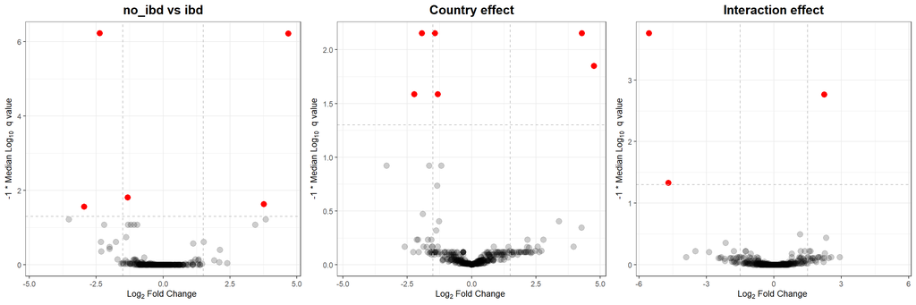

```r
# see the plot
volcano
```

**MaAsLin2**

Volcano plot

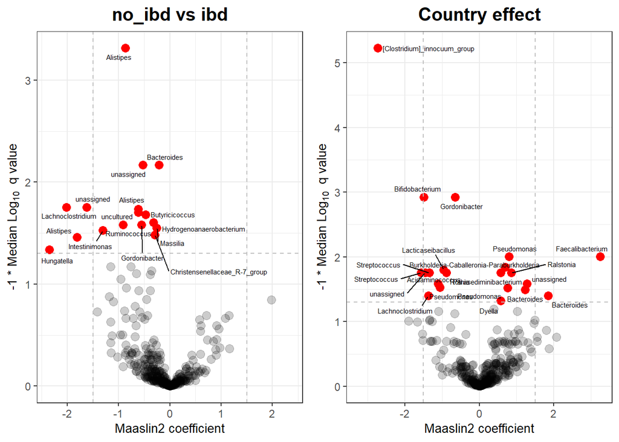

```r
volcano1 <- volcano_plot_maaslin(fit_data,filt_colon_uni_taxa) +
            ggtitle(paste(group[1], "vs", group[2]))

volcano2 <- volcano_plot_maaslin(fit_data,filt_colon_uni_taxa,variable="Country") +
            ggtitle("Country effect")

volcano <- ggarrange(volcano1,volcano2, ncol=2)

# see the results
volcano
```

**Group - Intersection**

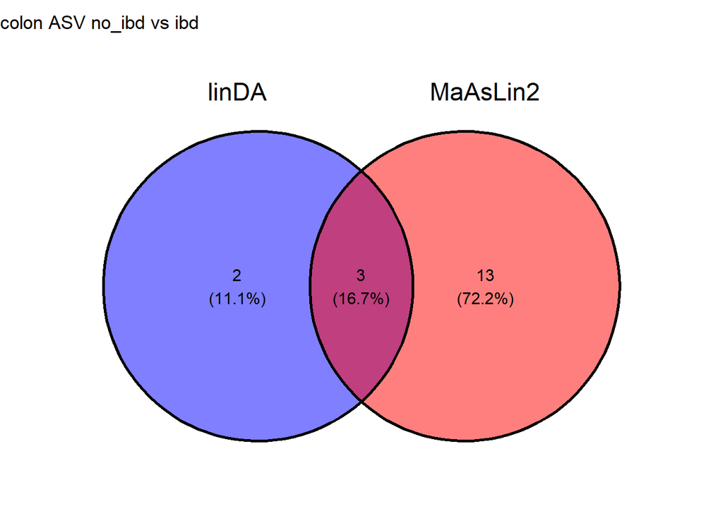

```r
intersection_results <- group_intersection(group, list_intersections, list_venns,
                                           linda.output, fit_data,
                                           raw_linda_results,
                                                                                      segment = segment,
                                           level=level)

list_intersections <- intersection_results[[1]]
list_venns <- intersection_results[[2]]
venn <- intersection_results[[3]]

# show the results
venn
```

**Interaction effect**

```r
list_interaction_significant <- country_interaction(group,
                                                    linda.output,
                                                    list_intersections,
                                                    filt_colon_uni_data,
                                                    filt_colon_uni_metadata,
                                                    segment=segment,
                                          level=level)

# see the result
## significant interaction effect
list_interaction_significant[[1]]
```

```r
## results for czech cohort
list_interaction_significant[[2]]
```

```
## [1] NA
```

```r
## results for norwegian cohort
list_interaction_significant[[3]]
```

```
## [1] NA
```

Removing problematic taxa

```r
list_intersections <- removing_interaction_problems(group,
                                                    list_interaction_significant,
                                                    list_intersections,
                                                    segment=segment,
                                                    level=level)
```

Basic statistics

```r
uni_df <-  merge(basic_univariate_statistics(linda_data,group),
                 raw_linda_results[[segment]][[group1]],
                 by="SeqID",all=TRUE)
```

```
## [1] "no_ibd"
## [1] "ibd"
## [1] "no_ibd"
## [1] "ibd"
```

```r
uni_df[["final_sig"]] <- uni_df$SeqID %in% list_intersections[[paste(segment,level,comparison_name)]][["SeqID"]]
uni_statistics[[segment]][[paste(level,comparison_name)]] <- uni_df

# for comparison
new_name <- paste(level,comparison_name)
addWorksheet(supplements_wb, sheetName = new_name)
writeData(supplements_wb, sheet = new_name, uni_df, rowNames=FALSE)
```

##### Visualization

Heatmap visualizing the linDA’s logFoldChange for taxa with p < 0.1.

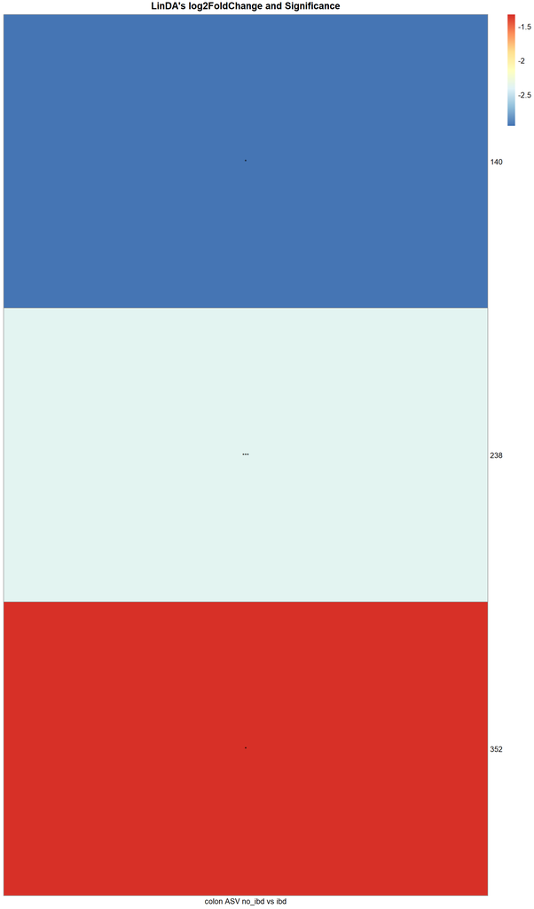

```r
list_heatmap <- list_intersections[grep(paste(segment,level),
                                  names(list_intersections),value=TRUE)]

if (length((list_heatmap[[1]][[1]]))>1){
p_heatmap_linda <- heatmap_linda(list_heatmap,colon_taxa_tab)
p_heatmap_linda
}
```

**Dot heatmap**

```
## min_clr -1.086093
## max_clr -0.4060013
## min_log -2.956456
## max_log -1.328115
```

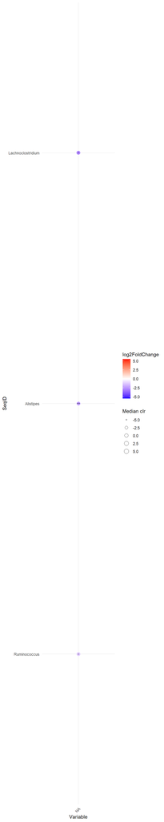

```r
if (length((list_heatmap[[1]][[1]]))>0){
dotheatmap_linda <- dot_heatmap_linda(list_heatmap,
                                      uni_statistics$colon[grepl(level,names(uni_statistics$colon))],
                                      colon_taxa_tab)
dotheatmap_linda
}
```

#### Phylum level

```r
level="phylum"
```

```r
path_maaslin="../intermediate_files/maaslin/Q3/Phylum/"
```

```r
raw_linda_results_phylum[[segment]] <- list()
linda_results_phylum[[segment]] <- list()
```

Aggregate taxa

```r
phylum_data <- aggregate_taxa(colon_asv_tab,
                             colon_taxa_tab,
                             taxonomic_level = "Phylum")

colon_phylum_tab <- phylum_data[[1]]
colon_phylum_taxa_tab <- phylum_data[[2]]
```

##### ibd vs no_ibd

```r
group <- c("no_ibd","ibd")
comparison_name <- paste0(group[1], " vs ",group[2])
```

**linDA**

```r
# prepare the data
linda_data <- binomial_prep(colon_phylum_tab,
                            colon_phylum_taxa_tab,
                            colon_metadata,
                            group, usage="linDA")
```

```
## Removing 1 ASV(s)
```

```r
filt_colon_uni_data <- linda_data[[1]]
filt_colon_uni_taxa <- linda_data[[2]]
filt_colon_uni_metadata <- linda_data[[3]]

# fit the model
linda.obj <- linda(filt_colon_uni_data,
                   filt_colon_uni_metadata,
                   formula = '~ Group * Country + (1|Patient)')
```

```
## 0  features are filtered!
## The filtered data has  337  samples and  10  features will be tested!
## Imputation approach is used.
## Fit linear mixed effects models ...
## Completed.
```

```r
linda.output <- linda.obj$output
linda.output <- linda_renaming(linda.output, group)

group1 <- paste0(group[1], " vs ","Group",group[2])
group2 <- paste0(group[1], " , ",group[2], " - CZ vs NO")
group3 <- paste0(group[1], " vs ","Group",group[2], ":CountryNO")

for (grp in c(group1,group2,group3)){
  raw_linda_results[[segment]][[grp]] <-
    rawlinda.df(linda.output,
                grp,
                filt_colon_uni_data,
                filt_colon_uni_taxa)

  linda_results[[segment]][[grp]] <-
    linda.df(linda.output,
             grp,
             filt_colon_uni_data,
             filt_colon_uni_taxa)
}
```

```r
# volcano plot
volcano_1 <- volcano_plot_linda(linda.output, group1,
                                taxa_table = filt_colon_uni_taxa) +
              ggtitle(paste(group,collapse=" vs "))
```

```
## Using Phylum for naming
```

```r
volcano_2  <- volcano_plot_linda(linda.output, group2,
                                 taxa_table = filt_colon_uni_taxa) +
              ggtitle("Country effect")
```

```
## Using Phylum for naming
```

```r
volcano_3 <- volcano_plot_linda(linda.output, group3,
                                taxa_table = filt_colon_uni_taxa) +
              ggtitle("Interaction effect")
```

```
## Using Phylum for naming
```

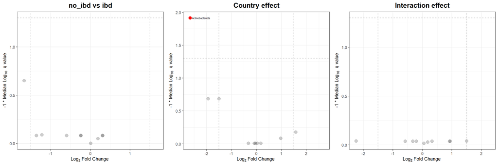

```r
volcano <- ggarrange(volcano_1,volcano_2,volcano_3, ncol=3)

# see the plot
volcano
```

**MaAsLin2**

Volcano plot

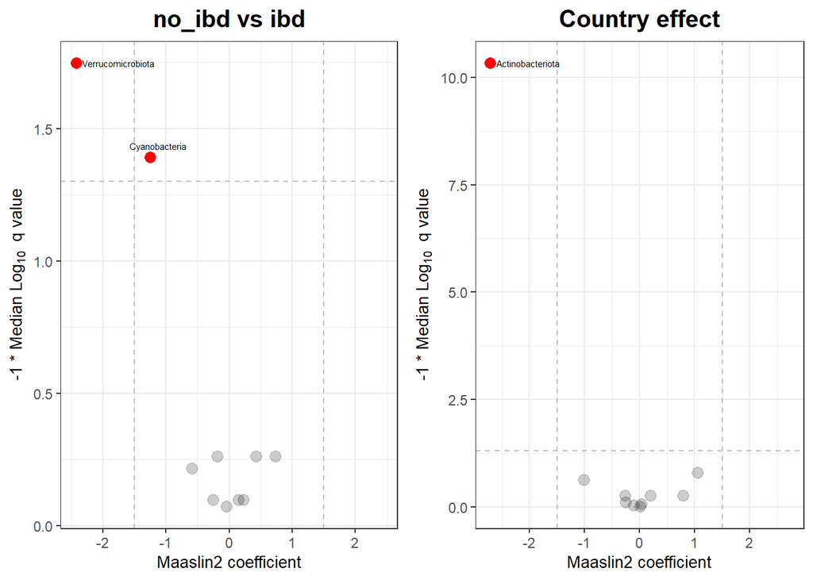

```r
volcano1 <- volcano_plot_maaslin(fit_data,filt_colon_uni_taxa) +
            ggtitle(paste(group[1], "vs", group[2]))

volcano2 <- volcano_plot_maaslin(fit_data,filt_colon_uni_taxa,variable="Country") +
            ggtitle("Country effect")

volcano <- ggarrange(volcano1,volcano2, ncol=2)

# see the results
volcano
```

**Group - Intersection**

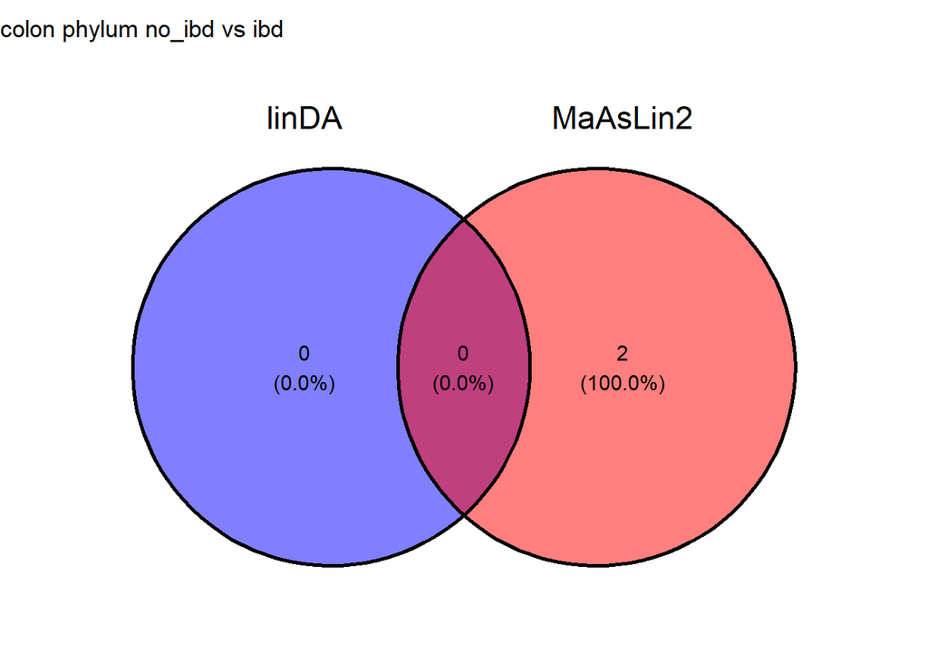

```r
intersection_results <- group_intersection(group, list_intersections, list_venns,
                                           linda.output, fit_data,
                                           raw_linda_results,
                                                                                      segment = segment,
                                           level=level)

list_intersections <- intersection_results[[1]]
list_venns <- intersection_results[[2]]
venn <- intersection_results[[3]]

# show the results
venn
```

**Interaction effect**

```r
list_interaction_significant <- country_interaction(group,
                                                    linda.output,
                                                    list_intersections,
                                                    filt_colon_uni_data,
                                                    filt_colon_uni_metadata,
                                                    segment=segment,
                                          level=level)

# see the result
## significant interaction effect
list_interaction_significant[[1]]
```

```r
## results for czech cohort
list_interaction_significant[[2]]
```

```
## [1] NA
```

```r
## results for norwegian cohort
list_interaction_significant[[3]]
```

```
## [1] NA
```

Removing problematic taxa

```r
list_intersections <- removing_interaction_problems(group,
                                                    list_interaction_significant,
                                                    list_intersections,
                                                    segment=segment,
                                                    level=level)
```

Basic statistics

```r
uni_df <-  merge(basic_univariate_statistics(linda_data,group),
                 raw_linda_results[[segment]][[group1]],
                 by="SeqID",all=TRUE)
```

```
## [1] "no_ibd"
## [1] "ibd"
## [1] "no_ibd"
## [1] "ibd"
```

```r
uni_df[["final_sig"]] <- uni_df$SeqID %in% list_intersections[[paste(segment,level,comparison_name)]][["SeqID"]]
uni_statistics[[segment]][[paste(level,comparison_name)]] <- uni_df

# for comparison
new_name <- paste(level,comparison_name)
addWorksheet(supplements_wb, sheetName = new_name)
writeData(supplements_wb, sheet = new_name, uni_df, rowNames=FALSE)
```

##### Visualization

Heatmap visualizing the linDA’s logFoldChange for taxa with p < 0.1.

```r
list_heatmap <- list_intersections[grep(paste(segment,level),
                                  names(list_intersections),value=TRUE)]

if (length((list_heatmap[[1]][[1]]))>1){
p_heatmap_linda <- heatmap_linda(list_heatmap,colon_taxa_tab)
p_heatmap_linda
}
```

**Dot heatmap**

```r
if (length((list_heatmap[[1]][[1]]))>0){
dotheatmap_linda <- dot_heatmap_linda(list_heatmap,uni_statistics$colon[grepl(level,names(uni_statistics$colon))],colon_taxa_tab)
dotheatmap_linda
}
```

#### Saving results

```r
# ALL DATA
saveWorkbook(supplements_wb,file.path(path,paste0("supplements_uni_analysis_wb_",segment,".xlsx")),overwrite = TRUE)

# SIGNIFICANT taxa
write.xlsx(list_intersections[grepl(segment,names(list_intersections))] %>%
            `names<-`(gsub(segment, "", names(
              list_intersections[grepl(segment,names(list_intersections))]))),
           file.path(path,paste0("supplements_significant_taxa_",segment,".xlsx")))
```

## Machine learning

```r
path = "../results/Q3/models"
```

### ElasticNet

```r
model="enet"
```

#### ASV level

```r
level="ASV"
```

##### ibd vs no_ibd

```r
group <- c("no_ibd","ibd")
comparison_name <- paste0(group[1], " vs ",group[2])
```

```r
model_name <- paste(comparison_name,level,segment)

# prepare the data
filt_colon_uni_data <- binomial_prep(colon_asv_tab,
                                     colon_taxa_tab,
                                     colon_metadata,
                                     group,
                                     usage="ml_clr",
                                     patient = TRUE)
```

```
## Removing 12 ASV(s)
```

```
## Removing 31 ASV(s)
```

```r
# fit the model
enet_model <- glmnet_binomial(filt_colon_uni_data,
                              sample_method = "atypboot",
                              outcome="Group",
                              N=10,
                              clust_var="Patient",
                              reuse=TRUE,
                              file=model_name,
                              Q="Q3")

# ROC
roc_c <- roc_curve(enet_model, group)

models_summ[[model_name]] <- enet_model$model_summary
models_cm[[model_name]] <- enet_model$conf_matrices$original
roc_cs[[model_name]] <- enet_model$kfold_rocobjs
betas[[model_name]] <- as.matrix(enet_model$betas)

# see the results
enet_model$model_summary %>% t()
```

```
##                                      [,1]
## alpha                           0.2000000
## lambda                          0.0269204
## auc                             1.0000000
## auc_czech                       1.0000000
## auc_no                          1.0000000
## auc_optimism_corrected          0.5847854
## auc_optimism_corrected_CIL      0.4688532
## auc_optimism_corrected_CIU      0.6771032
## accuracy                        0.9970326
## accuracy_czech                        NaN
## accuracy_no                     0.9959514
## accuracy_optimism_corrected     0.7870621
## accuracy_optimism_corrected_CIL 0.7325750
## accuracy_optimism_corrected_CIU 0.8465551
```

```r
enet_model$conf_matrices
```

```
## $original
##     Predicted
## True   0   1
##    0 275   0
##    1   1  61
##
## $czech
##     Predicted
## True  0  1
##    0 81  0
##    1  0  9
##
## $no
##     Predicted
## True   0   1
##    0 194   0
##    1   1  52
```

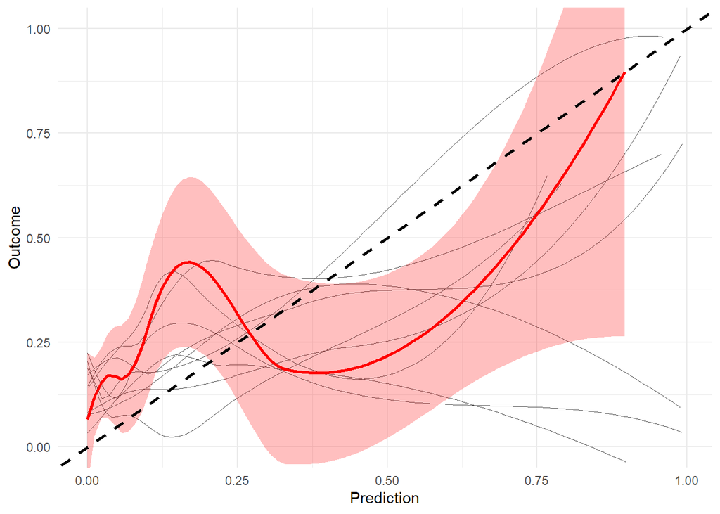

```r
enet_model$plot
```

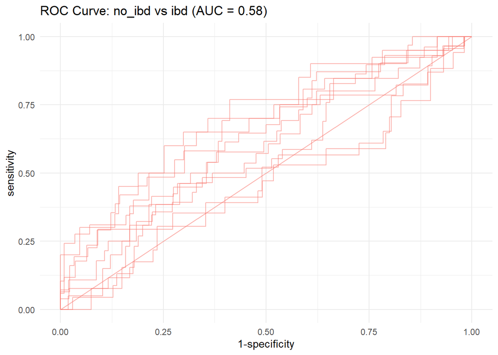

```r
roc_c
```

#### Genus level

```r
level="genus"
```

Aggregate taxa

```r
genus_data <- aggregate_taxa(colon_asv_tab,
                             colon_taxa_tab,
                             taxonomic_level = level)

colon_genus_tab <- genus_data[[1]]
colon_genus_taxa_tab <- genus_data[[2]]
```

##### ibd vs no_ibd

```r
group <- c("no_ibd","ibd")
comparison_name <- paste0(group[1], " vs ",group[2])
```

```r
model_name <- paste(comparison_name,level,segment)

# prepare the data
filt_colon_uni_data <- binomial_prep(colon_genus_tab,
                                     colon_genus_taxa_tab,
                                     colon_metadata,
                                     group,
                                     usage="ml_clr",
                                     patient = TRUE)
```

```
## Removing 7 ASV(s)
```

```r
# fit the model
enet_model <- glmnet_binomial(filt_colon_uni_data,
                              sample_method = "atypboot",
                              outcome="Group",
                              N=500,
                              clust_var="Patient",
                              reuse=TRUE,
                              file=model_name,
                              Q="Q3")

# ROC
roc_c <- roc_curve(enet_model, group)

# save the results
models_summ[[model_name]] <- enet_model$model_summary
models_cm[[model_name]] <- enet_model$conf_matrices$original
roc_cs[[model_name]] <- enet_model$kfold_rocobjs
betas[[model_name]] <- as.matrix(enet_model$betas)

# see the results
enet_model$model_summary %>% t()
```

```
##                                      [,1]
## alpha                           0.0000000
## lambda                          0.0511375
## auc                             0.9974194
## auc_czech                       0.9903978
## auc_no                          0.9988329
## auc_optimism_corrected          0.5347723
## auc_optimism_corrected_CIL      0.3713615
## auc_optimism_corrected_CIU      0.6774728
## accuracy                        0.9643917
## accuracy_czech                        NaN
## accuracy_no                     0.9676113
## accuracy_optimism_corrected     0.7344974
## accuracy_optimism_corrected_CIL 0.6380090
## accuracy_optimism_corrected_CIU 0.8145176
```

```r
enet_model$conf_matrices
```

```
## $original
##     Predicted
## True   0   1
##    0 275   0
##    1  12  50
##
## $czech
##     Predicted
## True  0  1
##    0 81  0
##    1  4  5
##
## $no
##     Predicted
## True   0   1
##    0 194   0
##    1   8  45
```

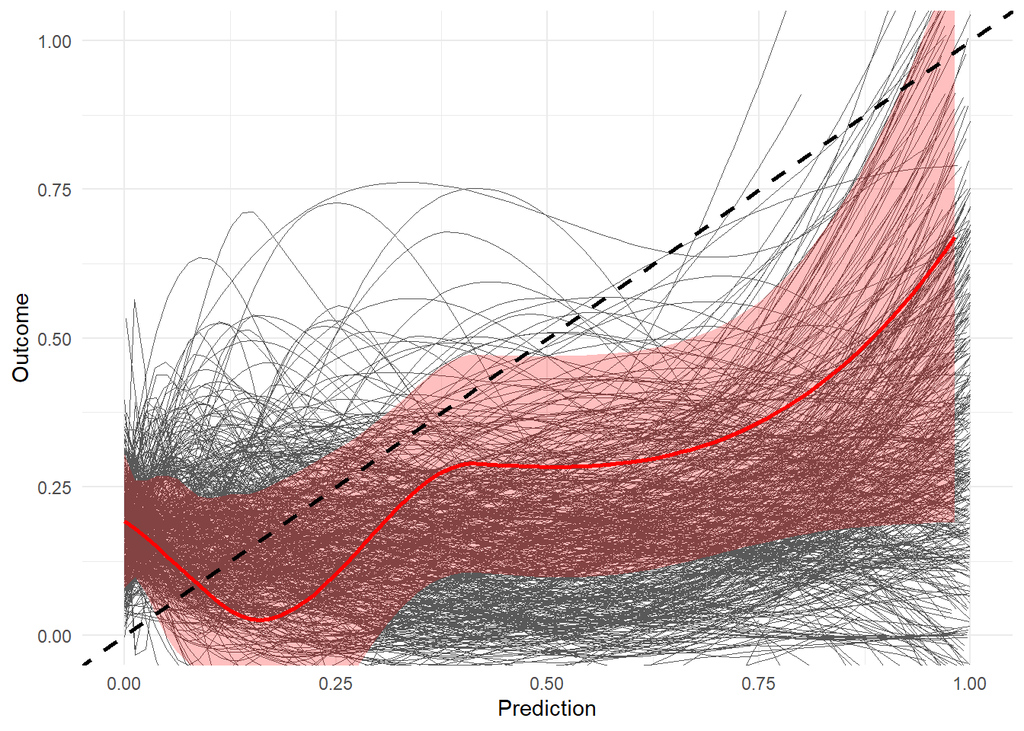

```r
enet_model$plot
```

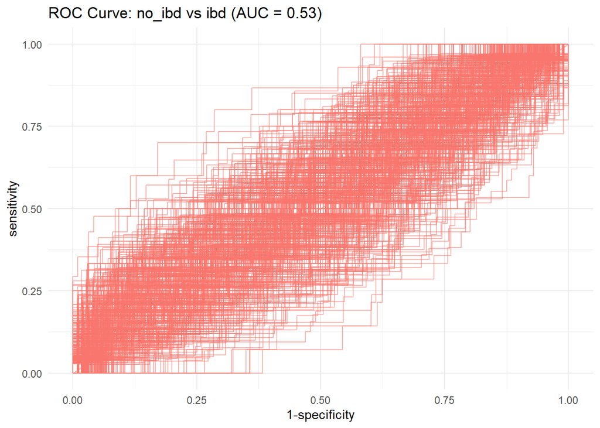

```r
roc_c
```

#### Saving results

```r
models_summ_df_colon <- do.call(rbind,
  models_summ[grep(segment,names(models_summ),value = TRUE)])

write.csv(models_summ_df_colon,file.path(path,paste0("elastic_net_",segment,".csv")))
```

### Supplementary models

#### CLR-transformed data

##### kNN

```r
model="knn"
```

###### ASV level

```r
level="ASV"
```

**ibd vs no_ibd**

```r
group <- c("no_ibd","ibd")
comparison_name <- paste0(group[1], " vs ",group[2])
```

```r
model_name <- paste(comparison_name,level,segment)

# prepare the data
filt_colon_uni_data <- binomial_prep(colon_asv_tab,
                                     colon_taxa_tab,
                                     colon_metadata,
                                     group, usage="ml_clr",
                                     patient = TRUE)
```

```
## Removing 12 ASV(s)
```

```
## Removing 31 ASV(s)
```

```r
# fit the model
knn_model <- knn_binomial(filt_colon_uni_data,
                              sample_method = "atypboot",
                              outcome="Group",
                              N=10,
                              clust_var="Patient",
                              reuse=TRUE,
                              file=model_name,
                              Q="Q3")

# ROC curve
roc_c <- roc_curve(knn_model, group)

# save the results
supplements_models[["models_summ"]][["knn_model"]][[model_name]] <- knn_model$model_summary
supplements_models[["roc_cs"]][["knn_model"]][[model_name]] <- knn_model$kfold_rocobjs

# see the results
knn_model$model_summary %>% t()
```

```
##                                       [,1]
## k                               30.0000000
## auc                              0.8623754
## auc_optimism_corrected           0.5444110
## auc_optimism_corrected_CIL       0.4910666
## auc_optimism_corrected_CIU       0.6912183
## accuracy                         0.8160237
## accuracy_optimism_corrected      0.7991877
## accuracy_optimism_corrected_CIL  0.7185896
## accuracy_optimism_corrected_CIU  0.8630052
```

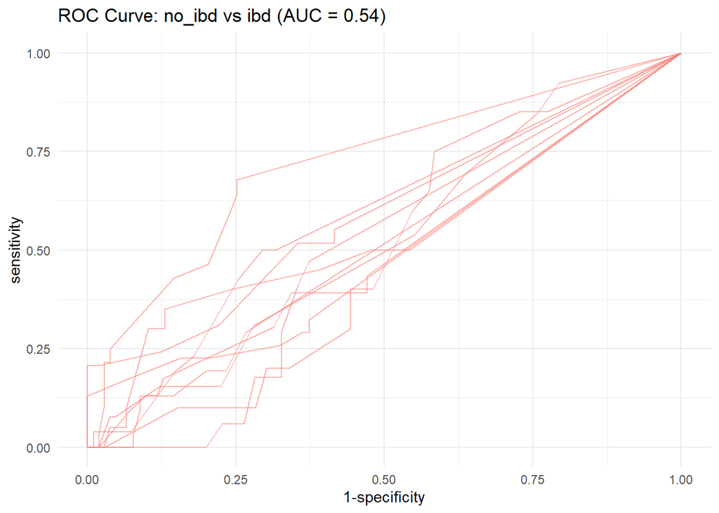

```r
roc_c
```

###### Genus level

```r
level="genus"
```

Aggregate taxa

```r
genus_data <- aggregate_taxa(colon_asv_tab,
                             colon_taxa_tab,
                             taxonomic_level = level)

colon_genus_tab <- genus_data[[1]]
colon_genus_taxa_tab <- genus_data[[2]]
```

**ibd vs no_ibd**

```r
group <- c("no_ibd","ibd")
comparison_name <- paste0(group[1], " vs ",group[2])
```

```r
model_name <- paste(comparison_name,level,segment)

# prepare the data
filt_colon_uni_data <- binomial_prep(colon_genus_tab,
                                     colon_genus_taxa_tab,
                                     colon_metadata,
                                     group,
                                     usage="ml_clr",
                                     patient = TRUE)
```

```
## Removing 7 ASV(s)
```

```r
# fit the model
knn_model <- knn_binomial(filt_colon_uni_data,
                              sample_method = "atypboot",
                              outcome="Group",
                              N=500,
                          clust_var="Patient",
                              reuse=TRUE,
                              file=model_name,
                              Q="Q3")

# ROC curve
roc_c <- roc_curve(knn_model, group)

# save the results
supplements_models[["models_summ"]][["knn_model"]][[model_name]] <- knn_model$model_summary
supplements_models[["roc_cs"]][["knn_model"]][[model_name]] <- knn_model$kfold_rocobjs


# see the results
knn_model$model_summary %>% t()
```

```
##                                       [,1]
## k                               26.0000000
## auc                              0.7980352
## auc_optimism_corrected           0.5610692
## auc_optimism_corrected_CIL       0.3920587
## auc_optimism_corrected_CIU       0.7211670
## accuracy                         0.8189911
## accuracy_optimism_corrected      0.7681945
## accuracy_optimism_corrected_CIL  0.6703894
## accuracy_optimism_corrected_CIU  0.8601162
```

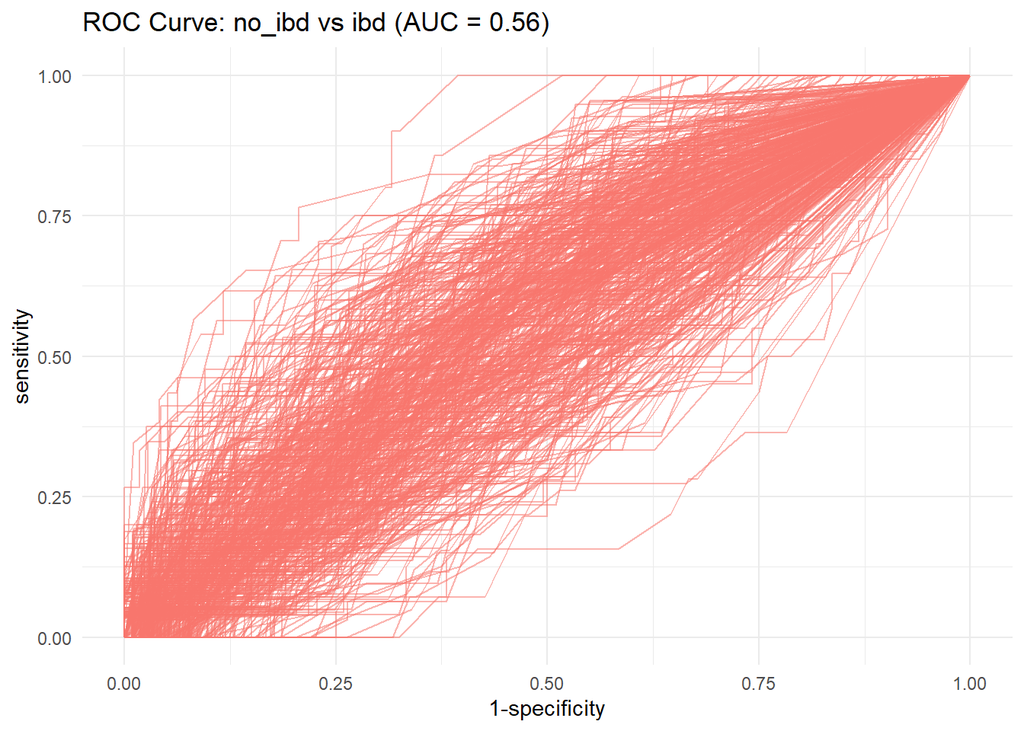

```r
roc_c
```

##### Random Forest

```r
model="rf"
```

###### ASV level

```r
level="ASV"
```

**ibd vs no_ibd**

```r
group <- c("no_ibd","ibd")
comparison_name <- paste0(group[1], " vs ",group[2])
```

```r
model_name <- paste(comparison_name,level,segment)

# prepare the data
filt_colon_uni_data <- binomial_prep(colon_asv_tab,
                                     colon_taxa_tab,
                                     colon_metadata,
                                     group, usage="ml_clr",
                                     patient = TRUE)
```

```
## Removing 12 ASV(s)
```

```
## Removing 31 ASV(s)
```

```r
# fit the model
rf_model <- rf_binomial(filt_colon_uni_data,
                              sample_method = "atypboot",
                              outcome="Group",
                              N=10,
                        clust_var="Patient",
                              reuse=TRUE,
                              file=model_name,
                              Q="Q3")

# ROC curve
roc_c <- roc_curve(rf_model, group)

# save the results
supplements_models[["models_summ"]][["rf_model"]][[model_name]] <- rf_model$model_summary
supplements_models[["roc_cs"]][["rf_model"]][[model_name]] <- rf_model$kfold_rocobjs

# see the results
rf_model$model_summary %>% t()
```

```
##                                 [,1]
## mtry                            "305"
## splitrule                       "gini"
## min.node.size                   "2"
## auc                             "1"
## auc_optimism_corrected          "0.6167552"
## auc_optimism_corrected_CIL      "0.5454906"
## auc_optimism_corrected_CIU      "0.7369122"
## accuracy                        "1"
## accuracy_optimism_corrected     "0.7941011"
## accuracy_optimism_corrected_CIL "0.7217323"
## accuracy_optimism_corrected_CIU "0.8426551"
```

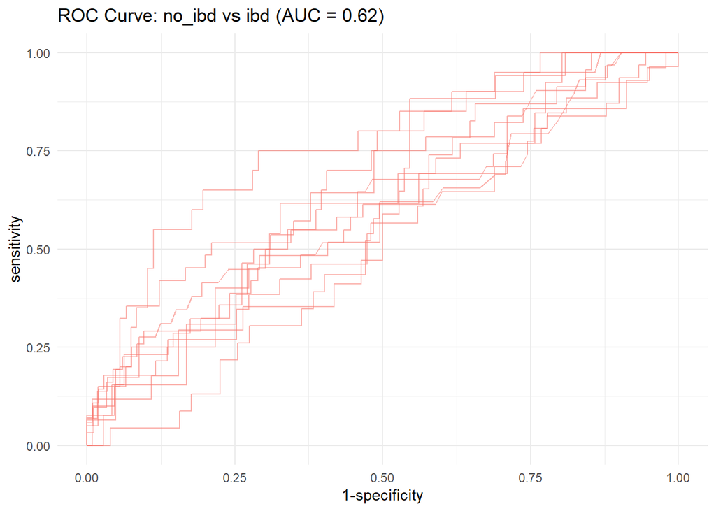

```r
roc_c
```

###### Genus level

```r
level="genus"
```

Aggregate taxa

```r
genus_data <- aggregate_taxa(colon_asv_tab,
                             colon_taxa_tab,
                             taxonomic_level = level)

colon_genus_tab <- genus_data[[1]]
colon_genus_taxa_tab <- genus_data[[2]]
```

**ibd vs no_ibd**

```r
group <- c("no_ibd","ibd")
comparison_name <- paste0(group[1], " vs ",group[2])
```

```r
model_name <- paste(comparison_name,level,segment)

# prepare the data
filt_colon_uni_data <- binomial_prep(colon_genus_tab,
                                     colon_genus_taxa_tab,
                                     colon_metadata,
                                     group,
                                     usage="ml_clr",
                                     patient = TRUE)
```

```
## Removing 7 ASV(s)
```

```r
# fit the model
rf_model <- rf_binomial(filt_colon_uni_data,
                              sample_method = "atypboot",
                              outcome="Group",
                              N=500,
                        clust_var="Patient",
                              reuse=TRUE,
                              file=model_name,
                              Q="Q3")

# ROC curve
roc_c <- roc_curve(rf_model, group)

# save the results
supplements_models[["models_summ"]][["rf_model"]][[model_name]] <- rf_model$model_summary
supplements_models[["roc_cs"]][["rf_model"]][[model_name]] <- rf_model$kfold_rocobjs

# see the results
rf_model$model_summary %>% t()
```

```
##                                 [,1]
## mtry                            "57"
## splitrule                       "gini"
## min.node.size                   "5"
## auc                             "1"
## auc_optimism_corrected          "0.5889984"
## auc_optimism_corrected_CIL      "0.4185411"
## auc_optimism_corrected_CIU      "0.7572976"
## accuracy                        "1"
## accuracy_optimism_corrected     "0.8018651"
## accuracy_optimism_corrected_CIL "0.7092983"
## accuracy_optimism_corrected_CIU "0.8800577"
```

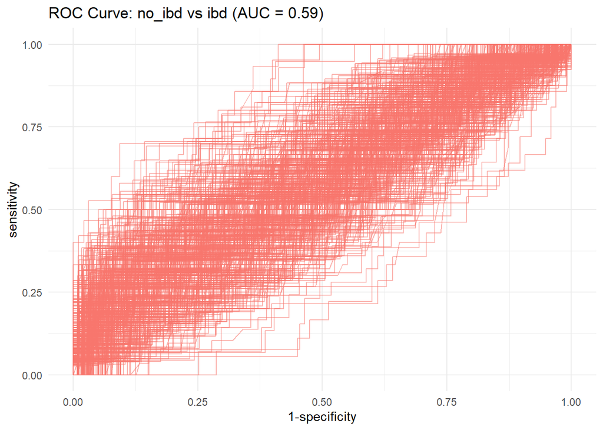

```r
roc_c
```

##### Gradient boosting

```r
model="gb"
```

###### ASV level

```r
level="ASV"
```

**ibd vs no_ibd**

```r
group <- c("no_ibd","ibd")
comparison_name <- paste0(group[1], " vs ",group[2])
```

```r
model_name <- paste(comparison_name,level,segment)

# prepare the data
filt_colon_uni_data <- binomial_prep(colon_asv_tab,
                                     colon_taxa_tab,
                                     colon_metadata,
                                     group, usage="ml_clr",
                                     patient = TRUE)
```

```
## Removing 12 ASV(s)
```

```
## Removing 31 ASV(s)
```

```r
# fit the model
gbm_model <- gbm_binomial(filt_colon_uni_data,
                              sample_method = "atypboot",
                              outcome="Group",
                              N=10,
                          clust_var="Patient",
                              reuse=TRUE,
                              file=model_name,
                              Q="Q3")

# ROC curve
roc_c <- roc_curve(gbm_model, group)

# save the results
supplements_models[["models_summ"]][["gbm_model"]][[model_name]] <- gbm_model$model_summary
supplements_models[["roc_cs"]][["gbm_model"]][[model_name]] <- gbm_model$kfold_rocobjs

# see the results
gbm_model$model_summary %>% t()
```

```
##                                        [,1]
## n.trees                         500.0000000
## interaction.depth                 5.0000000
## shrinkage                         0.1000000
## n.minobsinnode                   20.0000000
## auc                               1.0000000
## auc_optimism_corrected            0.5626808
## auc_optimism_corrected_CIL        0.4320810
## auc_optimism_corrected_CIU        0.6623252
## accuracy                          1.0000000
## accuracy_optimism_corrected       0.7827264
## accuracy_optimism_corrected_CIL   0.7149340
## accuracy_optimism_corrected_CIU   0.8368813
```

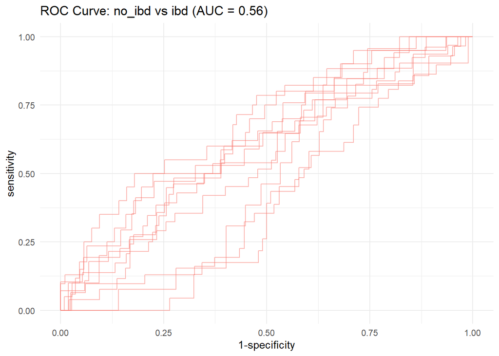

```r
roc_c
```

###### Genus level

```r
level="genus"
```

Aggregate taxa

```r
genus_data <- aggregate_taxa(colon_asv_tab,
                             colon_taxa_tab,
                             taxonomic_level = level)

colon_genus_tab <- genus_data[[1]]
colon_genus_taxa_tab <- genus_data[[2]]
```

**ibd vs no_ibd**

```r
group <- c("no_ibd","ibd")
comparison_name <- paste0(group[1], " vs ",group[2])
```

```r
model_name <- paste(comparison_name,level,segment)

# prepare the data
filt_colon_uni_data <- binomial_prep(colon_genus_tab,
                                     colon_genus_taxa_tab,
                                     colon_metadata,
                                     group,
                                     usage="ml_clr",
                                     patient = TRUE)
```

```
## Removing 7 ASV(s)
```

```r
# fit the model
gbm_model <- gbm_binomial(filt_colon_uni_data,
                              sample_method = "atypboot",
                              outcome="Group",
                              N=500,
                          clust_var="Patient",
                              reuse=TRUE,
                              file=model_name,
                              Q="Q3")

# ROC curve
roc_c <- roc_curve(gbm_model, group)

# save the results
supplements_models[["models_summ"]][["gbm_model"]][[model_name]] <- gbm_model$model_summary
supplements_models[["roc_cs"]][["gbm_model"]][[model_name]] <- gbm_model$kfold_rocobjs

# see the results
gbm_model$model_summary %>% t()
```

```
##                                        [,1]
## n.trees                         500.0000000
## interaction.depth                 3.0000000
## shrinkage                         0.1000000
## n.minobsinnode                   30.0000000
## auc                               1.0000000
## auc_optimism_corrected            0.5186094
## auc_optimism_corrected_CIL        0.3440184
## auc_optimism_corrected_CIU        0.6752125
## accuracy                          1.0000000
## accuracy_optimism_corrected       0.7792234
## accuracy_optimism_corrected_CIL   0.6917138
## accuracy_optimism_corrected_CIU   0.8604945
```

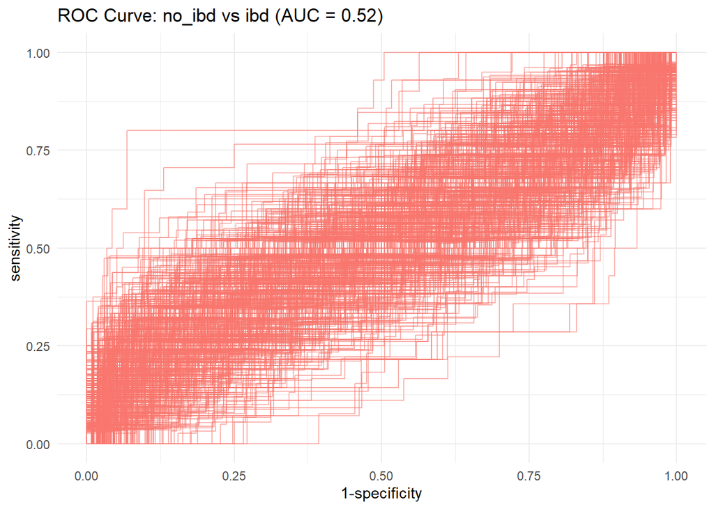

```r
roc_c
```

#### Saving results

```r
models_list <- list()

for (model_name in names(supplements_models$models_summ)){
  df <- do.call(rbind, supplements_models$models_summ[[model_name]])
  models_list[[model_name]] <- df
}

write.xlsx(models_list,
           file=file.path(path,paste0("supplements_models_",segment,".xlsx")),
           rowNames=TRUE)
```

## Results overview

#### Alpha diversity

```r
pc_observed[[segment]]
```

|  | Estimate | Std..Error | df | t.value | Pr...t.. | p.adj | sig |
| --- | --- | --- | --- | --- | --- | --- | --- |
| no_ibd vs Groupibd | 0.1950921 | 13.82796 | 330.2451 | 0.01410852 | 0.9887519 | 0.9887519 |  |
| no_ibd vs ibd - CZ vs NO | -0.5564541 | 18.19865 | 238.7330 | -0.03057667 | 0.9756327 | 0.9756327 |  |
| no_ibd vs Groupibd:CountryNO | -1.8801032 | 18.97070 | 263.1738 | -0.09910563 | 0.9211298 | 0.9211298 |  |

```r
pc_shannon[[segment]]
```

|  | Estimate | Std..Error | df | t.value | Pr...t.. | p.adj | sig |
| --- | --- | --- | --- | --- | --- | --- | --- |
| no_ibd vs Groupibd | -0.03758096 | 0.2036496 | 332.6214 | -0.1845374 | 0.8537043 | 0.8537043 |  |
| no_ibd vs ibd - CZ vs NO | -0.13887004 | 0.2624534 | 239.5922 | -0.5291227 | 0.5972102 | 0.5972102 |  |
| no_ibd vs Groupibd:CountryNO | 0.10067477 | 0.2745049 | 262.5470 | 0.3667503 | 0.7141007 | 0.7141007 |  |

```r
pc_simpson[[segment]]
```

|  | Estimate | Std..Error | df | t.value | Pr...t.. | p.adj | sig |
| --- | --- | --- | --- | --- | --- | --- | --- |
| no_ibd vs Groupibd | -0.01486898 | 0.03329984 | 332.9735 | -0.4465179 | 0.6555134 | 0.6555134 |  |
| no_ibd vs ibd - CZ vs NO | -0.03638323 | 0.04229537 | 240.1072 | -0.8602179 | 0.3905270 | 0.3905270 |  |
| no_ibd vs Groupibd:CountryNO | 0.03534433 | 0.04434254 | 261.8523 | 0.7970750 | 0.4261296 | 0.4261296 |  |

```r
pc_pielou[[segment]]
```

|  | Estimate | Std..Error | df | t.value | Pr...t.. | p.adj | sig |
| --- | --- | --- | --- | --- | --- | --- | --- |
| no_ibd vs Groupibd | -0.009062427 | 0.03441086 | 322.3526 | -0.2633595 | 0.7924418 | 0.7924418 |  |
| no_ibd vs ibd - CZ vs NO | -0.037593839 | 0.04154086 | 233.6604 | -0.9049846 | 0.3664057 | 0.3664057 |  |
| no_ibd vs Groupibd:CountryNO | 0.028323250 | 0.04392478 | 250.9237 | 0.6448125 | 0.5196377 | 0.5196377 |  |

Plots

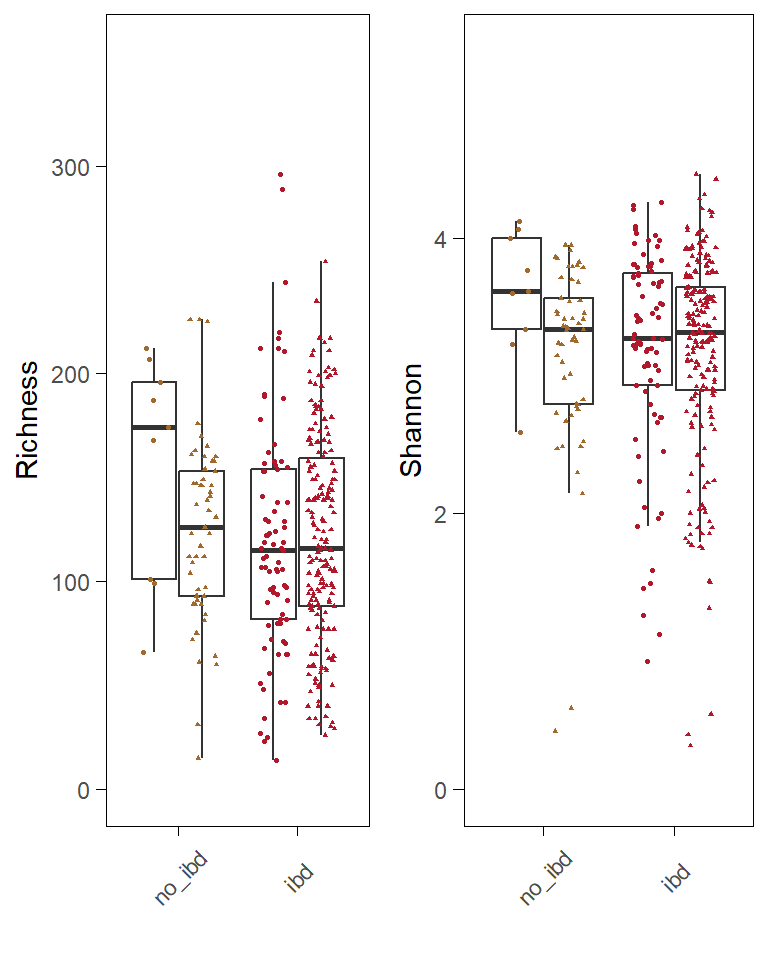

```r
alpha_div_plots[[paste(segment,"Country")]]
```

#### Beta diversity

**Main results**

```r
pairwise_aitchison_raw[[paste("genus", segment)]]
```

| pairs | Df | SumsOfSqs | F.Model | R2 | p.value | p.adjusted | sig |
| --- | --- | --- | --- | --- | --- | --- | --- |
| no_ibd vs ibd | 1 | 170.6779 | 1.096582 | 0.003248169 | 1.000 | 1.000 |  |
| no_ibd vs ibd , Country | 1 | 396.3687 | 2.546614 | 0.007543286 | 0.169 | 0.169 |  |
| no_ibd vs ibd : Country | 1 | 133.1442 | 0.855062 | 0.002533865 | 0.999 | 0.999 |  |

PCA

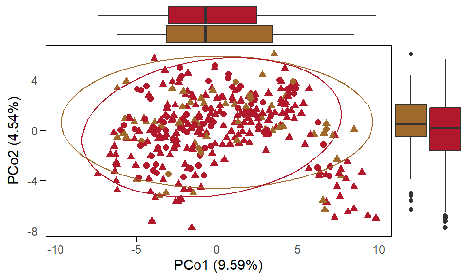

```r
pca_plots_list[[paste(segment,"genus custom")]]
```

**Supplements**

```r
knitr::kable(supplements_beta[!grepl("PCoA",names(supplements_beta)) & (grepl("genus",names(supplements_beta)))],
             digits = 3,
             caption = "Supplementary PERMANOVA results: Bray-curtis, Jaccard distances")
```

Supplementary PERMANOVA results: Bray-curtis, Jaccard distances

| pairs | Df | SumsOfSqs | F.Model | R2 | p.value | p.adjusted | sig |
| --- | --- | --- | --- | --- | --- | --- | --- |
| no_ibd vs ibd | 1 | 0.258 | 1.089 | 0.010 | 0.327 | 0.327 |  |
| no_ibd vs ibd , Country | 1 | 1.245 | 5.252 | 0.049 | 0.001 | 0.001 | *** |
| no_ibd vs ibd : Country | 1 | 0.111 | 0.464 | 0.004 | 0.970 | 0.970 |  |

| pairs | Df | SumsOfSqs | F.Model | R2 | p.value | p.adjusted | sig |
| --- | --- | --- | --- | --- | --- | --- | --- |
| no_ibd vs ibd | 1 | 0.333 | 1.048 | 0.010 | 0.350 | 0.350 |  |
| no_ibd vs ibd , Country | 1 | 1.179 | 3.711 | 0.035 | 0.001 | 0.001 | *** |
| no_ibd vs ibd : Country | 1 | 0.203 | 0.637 | 0.006 | 0.977 | 0.977 |  |

| pairs | Df | SumsOfSqs | F.Model | R2 | p.value | p.adjusted | sig |
| --- | --- | --- | --- | --- | --- | --- | --- |
| no_ibd vs ibd | 1 | 0.260 | 1.088 | 0.003 | 0.988 | 0.988 |  |
| no_ibd vs ibd , Country | 1 | 0.839 | 3.515 | 0.010 | 0.095 | 0.095 |  |
| no_ibd vs ibd : Country | 1 | 0.164 | 0.686 | 0.002 | 0.998 | 0.998 |  |

| pairs | Df | SumsOfSqs | F.Model | R2 | p.value | p.adjusted | sig |
| --- | --- | --- | --- | --- | --- | --- | --- |
| no_ibd vs ibd | 1 | 0.354 | 1.107 | 0.003 | 1.000 | 1.000 |  |
| no_ibd vs ibd , Country | 1 | 0.900 | 2.814 | 0.008 | 0.138 | 0.138 |  |
| no_ibd vs ibd : Country | 1 | 0.252 | 0.787 | 0.002 | 1.000 | 1.000 |  |

PCA

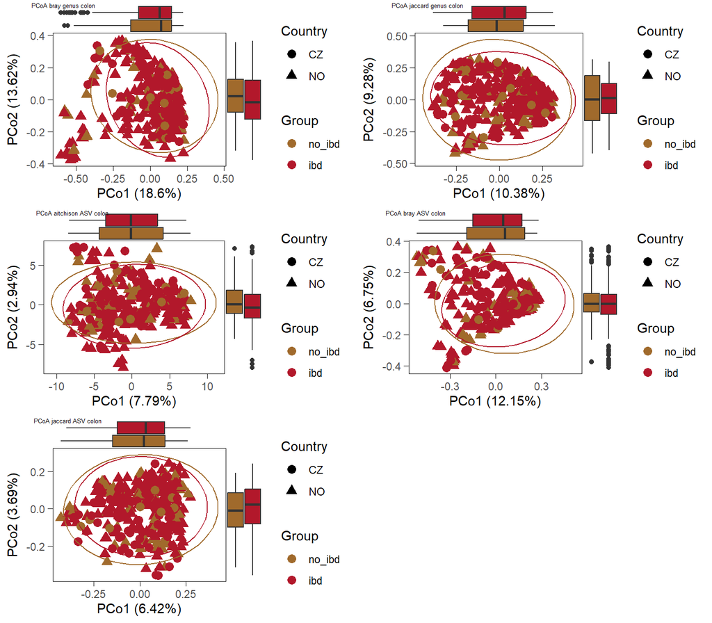

```r
plot_list <- supplements_beta[grepl("PCoA",names(supplements_beta)) &
                              grepl(segment,names(supplements_beta))]

ggarrange(plotlist = plot_list,
          labels=names(plot_list),
          font.label = list(size=5,face="plain"),
          ncol=2,nrow=3)
```

#### Univariate analysis

**Number of significant taxa**

```r
knitr::kable(as.data.frame(lapply(list_intersections,nrow)) %>% t() %>%
  `colnames<-`("Count") %>%
  `rownames<-`(c(names(list_intersections))),caption="Number of significant taxa")
```

Number of significant taxa

|  | Count |
| --- | --- |
| colon genus no_ibd vs ibd | 0 |
| colon ASV no_ibd vs ibd | 3 |
| colon phylum no_ibd vs ibd | 0 |

#### Machine learning

**Main models**

Summary

```r
knitr::kable(models_summ_df_colon %>% dplyr::select(
"alpha","lambda",
"auc_optimism_corrected",
"auc_optimism_corrected_CIL",
"auc_optimism_corrected_CIU"),
             digits=3,caption="Elastic net results")
```

Elastic net results

|  | alpha | lambda | auc_optimism_corrected | auc_optimism_corrected_CIL | auc_optimism_corrected_CIU |
| --- | --- | --- | --- | --- | --- |
| no_ibd vs ibd ASV colon | 0.2 | 0.027 | 0.585 | 0.469 | 0.677 |
| no_ibd vs ibd genus colon | 0.0 | 0.051 | 0.535 | 0.371 | 0.677 |

**ROC - ASV level**

```
## [1] "no_ibd vs ibd ASV colon"
```

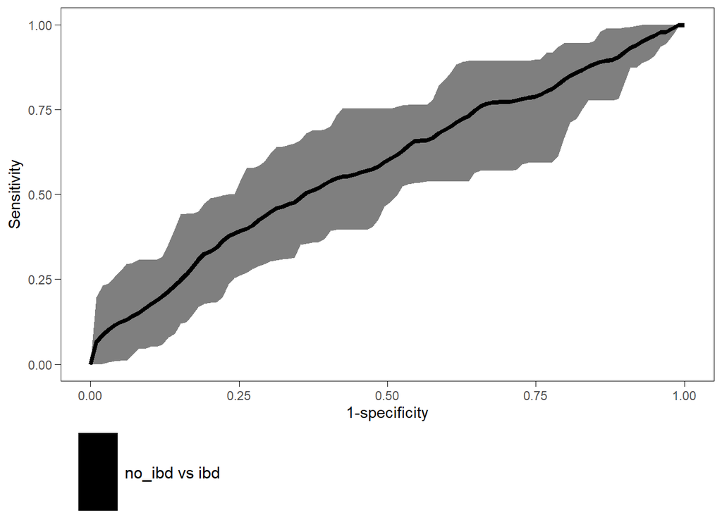

```r
roc_curve_all_custom(roc_cs[3],
                     Q="Q3",
                     model_name="enet_model")
```

**ROC - Genus level**

```
## [1] "no_ibd vs ibd genus colon"
```

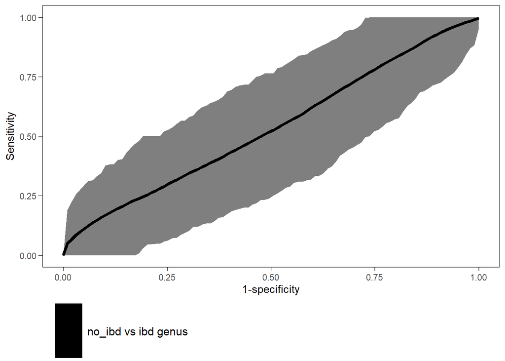

```r
roc_curve_all_custom(roc_cs[4],Q="Q3",
                     model_name="enet_model")
```

**Supplementary models**

```r
# Build final dataframe
models_list[["enet_model"]] <- rbind(models_summ_df_ileum,models_summ_df_colon)
final_df <- tibble(row_names = rownames(models_list[[1]]))

# Loop through models and extract required values
for (model_name in names(models_list)) {
  model_df <- models_list[[model_name]]

  # Combine AUC_optimism_corrected with its CI values
  final_df[[model_name]] <- paste0(
    round(model_df$auc_optimism_corrected, 3),
    " (", round(model_df$auc_optimism_corrected_CIL, 3), "; ",
    round(model_df$auc_optimism_corrected_CIU, 3), ")"
  )
}

knitr::kable(final_df, caption="All models")
```

All models

| row_names | knn_model | rf_model | gbm_model | enet_model |
| --- | --- | --- | --- | --- |
| ibd vs no_ibd ASV terminal_ileum | 0.41 (0.205; 0.564) | 0.845 (0.657; 0.947) | 0.785 (0.646; 0.93) | 0.418 (0.042; 0.617) |
| ibd vs no_ibd genus terminal_ileum | 0.647 (0.413; 0.857) | 0.698 (0.474; 0.888) | 0.638 (0.416; 0.858) | 0.582 (0.304; 0.804) |
| no_ibd vs ibd ASV colon | 0.544 (0.491; 0.691) | 0.617 (0.545; 0.737) | 0.563 (0.432; 0.662) | 0.585 (0.469; 0.677) |
| no_ibd vs ibd genus colon | 0.561 (0.392; 0.721) | 0.589 (0.419; 0.757) | 0.519 (0.344; 0.675) | 0.535 (0.371; 0.677) |

```r
write.csv(final_df,file=file.path(path,"AUC_all_models.csv"),row.names = FALSE)
```

**ROC - genus**

```r
rocs_list <- supplements_models$roc_cs
rocs_list[["enet_model"]] <- roc_cs
plot_list <- list()

for (model_name in names(rocs_list)) {
  plot_list[[model_name]] <- roc_curve_all_custom(rocs_list[[model_name]][4],
                       Q="Q3",
                       model_name=model_name)
}
```

```
## [1] "no_ibd vs ibd genus colon"
```

```
## [1] "no_ibd vs ibd genus colon"
```

```
## [1] "no_ibd vs ibd genus colon"
```

```
## [1] "no_ibd vs ibd genus colon"
```

```r
p <- ggarrange(plotlist = plot_list,labels = names(rocs_list),font.label = list(face="plain",size=7))
```

# Paper-ready visualizations

## Alpha diversity

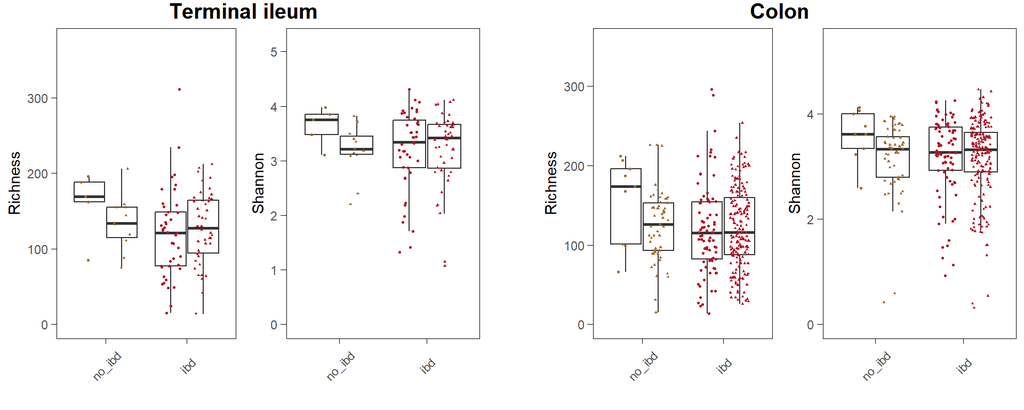

```r
p_A <- alpha_div_plots$`terminal_ileum Country` +
  ggtitle("Terminal ileum")+
  theme(plot.title = element_text(hjust=0.5,face = "bold",size = 15))

p_B <-  alpha_div_plots$`colon Country` +
  ggtitle("Colon") +
  theme(plot.title = element_text(hjust=0.5,face = "bold",size = 15))

Q3_alpha <- ggarrange(p_A,ggplot() + theme_minimal(),p_B,nrow=1, ncol=3,
                      widths = c(1,0.1,1))
Q3_alpha
```

## Beta diversity

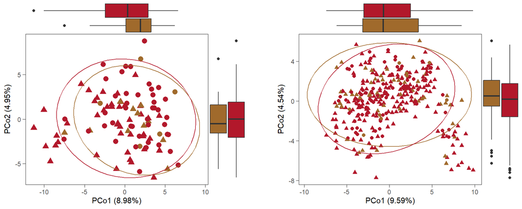

```r
pca_ti <- pca_plots_list$`terminal_ileum genus custom`
pca_colon <- pca_plots_list$`colon genus custom`

genus_Q3_beta <- ggarrange(pca_ti,
                           ggplot() + theme_minimal(),
                           pca_colon,ncol=3,
                           widths = c(1,0.1,1))
genus_Q3_beta
```

**Alpha + Beta diversity**

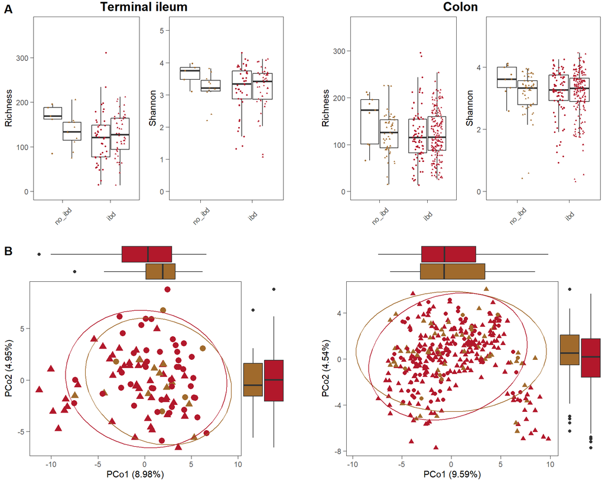

```r
alpha_beta <- ggarrange(Q3_alpha,genus_Q3_beta,
                        ncol = 1,nrow=2,labels = c("A","B"))
alpha_beta
```

## Elastic net

Genus level

```r
models_to_plot <- c("knn_model","rf_model","gbm_model","enet_model")
names(models_to_plot) <- c("kNN","RF","GBoost","ENET")

# ILEUM
plot_list_ileum <- list()
for (model_name in models_to_plot) {
  plot_list_ileum[[model_name]] <-
    roc_curve_all_custom(rocs_list[[model_name]][2],
                       Q="Q3",
                       model_name=model_name,legend = FALSE) +
    ggtitle(names(models_to_plot)[which(model_name==models_to_plot)]) +
    theme(plot.title = element_text(face = "bold",size = 10))
}
```

```
## [1] "ibd vs no_ibd genus terminal_ileum"
```

```
## [1] "ibd vs no_ibd genus terminal_ileum"
```

```
## [1] "ibd vs no_ibd genus terminal_ileum"
```

[output not shown]

```r
roc_curve_ti <- ggarrange(plotlist = plot_list_ileum)

# COLON

plot_list_colon <- list()
for (model_name in models_to_plot) {
  plot_list_colon[[model_name]] <-
    roc_curve_all_custom(rocs_list[[model_name]][c(4)],
                       Q="Q3",
                       model_name=model_name,legend = FALSE) +
    ggtitle(names(models_to_plot)[which(model_name==models_to_plot)]) +
    theme(plot.title = element_text(face = "bold",size = 10))
}
```

```
## [1] "no_ibd vs ibd genus colon"
```

```
## [1] "no_ibd vs ibd genus colon"
```

```
## [1] "no_ibd vs ibd genus colon"
```

```
## [1] "no_ibd vs ibd genus colon"
```

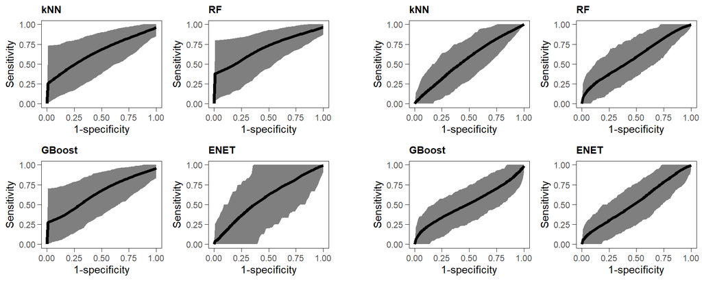

```r
roc_curve_colon <- ggarrange(plotlist = plot_list_colon)


roc_curve_plot <- ggarrange(roc_curve_ti,
                            ggplot() + theme_minimal(),
                            roc_curve_colon,
                            ncol=3, widths = c(1,0.1,1))
roc_curve_plot
```

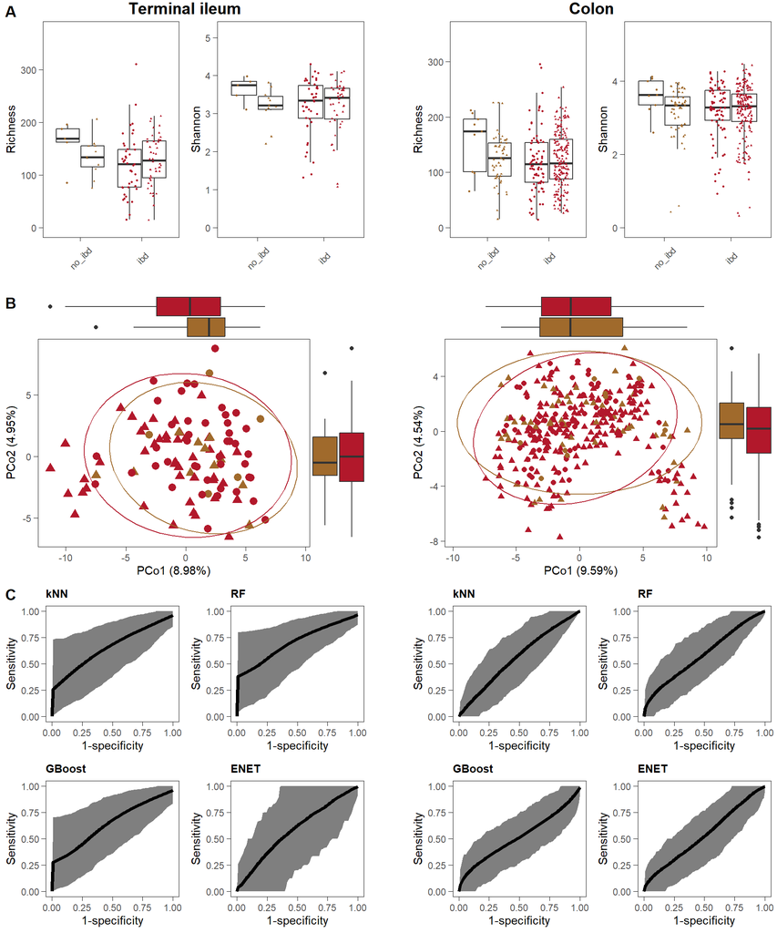

```r
alpha_beta_elastic <- ggarrange(Q3_alpha,genus_Q3_beta,roc_curve_plot,
                        ncol = 1,nrow=3,labels = LETTERS,heights = c(1,1,1.2))
alpha_beta_elastic
```

```r
alpha_beta_elastic <- ggarrange(alpha_beta_elastic,ggplot() + theme_minimal(),ncol=2,
                                widths = c(1,0.15))
```

## DAA

[figure not shown]

```r
if (exists("dot_heatmap_ileum")){
 p_ileum <- dot_heatmap_ileum +
  ggtitle("Terminal ileum") +
  theme(plot.title = element_text(hjust=0.5,face = "bold",size = 15),
        legend.position = "none")
}

if (exists("dot_heatmap_colon")){
  p_colon <- dot_heatmap_colon  +
  ggtitle("Colon") +
  theme(plot.title = element_text(hjust=0.5,face = "bold",size = 15),
        legend.position = "none")
}

if (exists("p_ileum") | exists("p_colon")){
  heatmap_plot <- ggarrange(p_ileum,
                          p_colon,
                          ncol = 2,labels=c("A","B"))
  heatmap_plot
}
```